# Exploration of Amazon consumer products reviews

## Preliminary Wrangling

> This investigation explores the Amazon US marketplace reviews dataset containing approximately 7 million unique reviews.

```python
# import all packages and set plots to be embedded inline
import numpy as np
import pandas as pd
import matplotlib.pyplot as plt
import matplotlib.dates as mdates
from matplotlib.ticker import AutoMinorLocator
import seaborn as sb
import re
import random
#random.seed(42)
import statistics

%matplotlib inline
```

```python
#Data is loaded from a TSV file. Bad lines are dropped as fixing these manually will take too much time
#for the low number of lines with errors.
reviews=pd.read_csv(r"amazon_reviews_multilingual_US_v1_00.tsv", sep="\t", error_bad_lines=False, header=0)
```

[output not shown]

```python
#View the unique items in the product category.
reviews.product_category.unique()
```

```
array(['Books', 'Music', 'Video', 'Video DVD', 'Toys', 'Tools',
       'Office Products', 'Video Games', 'Software',
       'Digital_Music_Purchase', 'Home Entertainment', 'Electronics',
       'Digital_Ebook_Purchase', 'Digital_Video_Download', 'Kitchen',
       'Camera', 'Outdoors', 'Musical Instruments', 'Sports', 'Watches',
       'PC', 'Home', 'Wireless', 'Beauty', 'Baby', 'Home Improvement',
       'Apparel', 'Shoes', 'Lawn and Garden', 'Mobile_Electronics',
       'Health & Personal Care', 'Grocery', 'Luggage',
       'Personal_Care_Appliances', 'Automotive', 'Mobile_Apps',
       'Furniture', '2012-12-22', 'Pet Products'], dtype=object)
```

```python
#View the data that has a product category of a date.
reviews.query("product_category == '2012-12-22'")
```

|  | marketplace | customer_id | review_id | product_id | product_parent | product_title | product_category | star_rating | helpful_votes | total_votes | vine | verified_purchase | review_headline | review_body | review_date |
| --- | --- | --- | --- | --- | --- | --- | --- | --- | --- | --- | --- | --- | --- | --- | --- |
| 1852794 | US | 49422747 | R2T9JZNQ996WRC | 1568652240 | 569473707 | Emma (Large Print)\tBooks\t5\t0\t0\tN\tY\tFoll... | 2012-12-22 | NaN | NaN | NaN | NaN | NaN | NaN | NaN | NaN |

```python
#View the data string in the product title
list(reviews[reviews.review_id=="R2T9JZNQ996WRC"].product_title)
```

```
['Emma (Large Print)\tBooks\t5\t0\t0\tN\tY\tFollows Austen\'s book closley\tI have the movie with Ms Paltrow starring, so I bought the book to see how it matched. Very well done.\t2012-12-22\nUS\t7209000\tR1MZOZGBLVKYVP\tB003E8P9G0\t446279348\tThe Kane Chronicles, Book One: The Red Pyramid\tDigital_…
```

```python
#Drop this line as it appears to have been parsed wrong because of the extra "/t" in the title column and there are a lot
#of extra reviews in this title string.
reviews.drop(reviews.loc[reviews.product_category.isin(['2012-12-22'])].index, inplace=True)
reviews.product_category.unique()
```

```
array(['Books', 'Music', 'Video', 'Video DVD', 'Toys', 'Tools',
       'Office Products', 'Video Games', 'Software',
       'Digital_Music_Purchase', 'Home Entertainment', 'Electronics',
       'Digital_Ebook_Purchase', 'Digital_Video_Download', 'Kitchen',
       'Camera', 'Outdoors', 'Musical Instruments', 'Sports', 'Watches',
       'PC', 'Home', 'Wireless', 'Beauty', 'Baby', 'Home Improvement',
       'Apparel', 'Shoes', 'Lawn and Garden', 'Mobile_Electronics',
       'Health & Personal Care', 'Grocery', 'Luggage',
       'Personal_Care_Appliances', 'Automotive', 'Mobile_Apps',
       'Furniture', 'Pet Products'], dtype=object)
```

```python
#View the dataframe's info
print(reviews.info(null_counts=True ))
```

```
<class 'pandas.core.frame.DataFrame'>
Int64Index: 6900885 entries, 0 to 6900885
Data columns (total 15 columns):
marketplace          6900885 non-null object
customer_id          6900885 non-null int64
review_id            6900885 non-null object
product_id           6900885 non-null object
product_parent       6900885 non-null int64
product_title        6900885 non-null object
product_category     6900885 non-null object
star_rating          6900885 non-null float64
helpful_votes        6900885 non-null float64
total_votes          6900885 non-null float64
vine                 6900885 non-null object
verified_purchase    6900885 non-null object
review_headline      6900811 non-null object
review_body          6900810 non-null object
review_date          6900562 non-null object
dtypes: float64(3), int64(2), object(10)
memory usage: 842.4+ MB
None
```

```python
#Investigate the reason that a few reviews have NaN for a date
dateless = reviews.loc[reviews['review_date'].isin(reviews.review_date.dropna().unique())==False]
dateless.head()
```

|  | marketplace | customer_id | review_id | product_id | product_parent | product_title | product_category | star_rating | helpful_votes | total_votes | vine | verified_purchase | review_headline | review_body | review_date |
| --- | --- | --- | --- | --- | --- | --- | --- | --- | --- | --- | --- | --- | --- | --- | --- |
| 142642 | US | 52767614 | RJBEAQJ92LS61 | B00003CXDG | 765637830 | Mission: Impossible 2 (Widescreen Edition) | Video DVD | 2.0 | 0.0 | 0.0 | N | N | Technology is not always beneficial -\tespecia... | 2001-03-08 | NaN |
| 186564 | US | 50374272 | R2LXX6V7B1PICZ | B00005OB0A | 321992753 | Fever | Music | 5.0 | 0.0 | 0.0 | N | N | The music you were playing really blew my mind... | 2001-10-25 | NaN |
| 217791 | US | 42627253 | R1CRCYSML85MB4 | B00005JKZQ | 167276143 | Showtime | Video DVD | 5.0 | 5.0 | 6.0 | N | N | It's............SHOWTIME!!!!!\tShowtime is the... | 2002-03-16 | NaN |
| 235044 | US | 52442862 | R1YZIXBH6AVF4E | B00000JMQC | 79142420 | Return to Oz [VHS] | Video | 5.0 | 6.0 | 7.0 | N | N | The Wizard of Oz it is not--should not be!\tFo... | 2002-06-10 | NaN |
| 239621 | US | 47692344 | R12KVFMZYPXNF6 | B00003CWL6 | 304141589 | American Beauty (1999) | Video DVD | 5.0 | 1.0 | 3.0 | N | N | It's just STUFF!!!\t\\American Beauty\\" is in... | 2002-06-30 | NaN |

```python
#It seems there was an issue during the reading of the TSV file and the review titles used a tab space. Where read_csv was
#looking for a "\t" delimiter

#Investigate the titles for each of the reviews to see if there is any thing unusual
#As this is a very large and long list, a random sample of 5 were chosen.
DL_random_list = random.sample(list(dateless.review_id), 5)
for i in DL_random_list:
    print(re.split("\t", list(dateless[dateless.review_id==i].review_headline)[0])[0])
```

```
It's............SHOWTIME!!!!!
 It was great to read it again
 I know I'm late discovering this series but I'm so glad I did
 Fantastic movie. Very deliberate however well worth the patience
Maybe the best...
```

```python
#Investigate the body of the dateless reviews to see if there is anything unusual.
for i in DL_random_list:
    print(re.split("\t", list(dateless[dateless.review_id==i].review_headline)[0])[1:])
```

```
['Showtime is the Reality-TV era\'s answer to Cop/Buddy movies like the Lethal Weapon series. When a dedicated detective (Robert De Niro) shoots a TV camera during a bust, the Network offers the LAPD a choice: A lawsuit, or the use of De Niro for a reality based show. The camera-shy de Niro is not t…
["Agatha's first mystery.  I read it years ago but couldn't remember &#34;who done it.&#34;  It was great to read it again.  I love the way she builds her characters and the way she fools us into suspecting the wrong person.", '2014-12-21\nUS', '22743572', 'R17TCT8I80YDOR', 'B00QW8TYWO', '828652896'…
["All I can say is, &#34;wow.&#34; I know I'm late discovering this series but I'm so glad I did. After a co-worker told me how she stayed up til 3am this series my interest was peaked. I didn't think I would like this season as much as the first, but I actually liked it more. Very well written.", '…
["&#34;I drink your milkshake! I drink it all up!&#34; Fantastic movie. Very deliberate however well worth the patience. Daniel day Lewis' role is one of the best performances I have ever seen on screen. His character is loved and yet hated by the end of the movie.", '2015-05-21\nUS', '44855737', 'R…
["...Maybe better than all the rest / 'Maybe' is a wrapper for a value that's possibly null...&#34;<br /><br />For a long time now, Haskell has been a computer science talisman: what the *real* nerds dug. A purely functional programming language that could still do everything you needed to write usa…
```

```python
#It seems like there are a lot of other reviews mixed into the body of some of the dateless reviews.
#As there are a very large number of total reviews, and wrangling the data to sort out the 300 or so that need to be fixed,
#I have decided to drop these rows.
reviews.drop(dateless.index, inplace=True)
reviews.loc[reviews['review_date'].isin(reviews.review_date.dropna().unique())==False]
```

|  | marketplace | customer_id | review_id | product_id | product_parent | product_title | product_category | star_rating | helpful_votes | total_votes | vine | verified_purchase | review_headline | review_body | review_date |
| --- | --- | --- | --- | --- | --- | --- | --- | --- | --- | --- | --- | --- | --- | --- | --- |

```python
#Investigate the reviews where there is no headline to see if there is anything unusual.
reviews.loc[reviews['review_headline'].isin(reviews.review_headline.dropna().unique())==False]
```

|  | marketplace | customer_id | review_id | product_id | product_parent | product_title | product_category | star_rating | helpful_votes | total_votes | vine | verified_purchase | review_headline | review_body | review_date |
| --- | --- | --- | --- | --- | --- | --- | --- | --- | --- | --- | --- | --- | --- | --- | --- |
| 144995 | US | 51263804 | RRR6EK045G5YL | 630438551X | 212477251 | Romeo & Juliet [VHS] | Video | 5.0 | 4.0 | 8.0 | N | N | NaN | I consider myself to be a pretty much diehard ... | 2001-03-21 |
| 274671 | US | 34490235 | R25MC0QXPV5CRZ | 6305949980 | 664817538 | The Nightmare Before Christmas (Special Edition) | Video DVD | 4.0 | 1.0 | 6.0 | N | N | NaN | Three words, \\"BEST MOVIE EVER.\\" If you hav... | 2002-12-11 |
| 373447 | US | 23532323 | R1MNPI81JJ62NI | B0000DD7NL | 868764779 | The Diary of Alicia Keys | Music | 5.0 | 0.0 | 2.0 | N | N | NaN | I love this cd! My favorite two songs are:<br... | 2004-01-12 |
| 450489 | US | 43058957 | RIHK7J9KBB62V | B00005V3Z4 | 681790048 | Donnie Darko (Widescreen Edition) | Video DVD | 4.0 | 3.0 | 8.0 | N | N | NaN | It actually is pretty hard to classify this mo... | 2004-11-18 |
| 515646 | US | 34215909 | R1HAKDWL5X86B9 | B00014NE62 | 59241661 | Maurice - The Merchant Ivory Collection | Video DVD | 4.0 | 2.0 | 3.0 | N | N | NaN | Goes at quite a steady pace, however, this is ... | 2005-08-12 |
| 522262 | US | 36882963 | R2VEG37XSHHQMO | B0002Y4TTC | 773850099 | Blind Guardian - Imaginations Through the Look... | Video DVD | 3.0 | 1.0 | 8.0 | N | N | NaN | This is a beautifully packaged 2-disc DVD edit... | 2005-09-04 |
| 546262 | US | 24610674 | R3NODAYWJSH67Y | B000BM6AVA | 828472430 | Hypnotize | Music | 5.0 | 2.0 | 4.0 | N | N | NaN | It's a warm, peaceful afternoon in the upstand... | 2005-11-28 |
| 550148 | US | 16196376 | R1DUI7MJ3FPONG | B0001YRVN4 | 745272701 | Star Wars Trilogy (A New Hope / The Empire Str... | Video DVD | 5.0 | 4.0 | 10.0 | N | N | NaN | What's all this I hear about people complainin... | 2005-12-12 |
| 567259 | US | 22947656 | R1ABIC2ULD2TCB | B000AP2ZDK | 577609284 | Donuts | Music | 5.0 | 112.0 | 124.0 | N | N | NaN | This isn't Dilla's best work, far from it real... | 2006-02-16 |
| 568389 | US | 42224700 | R3QMAWGAVYTR9F | B00001U0E1 | 475263130 | Shakespeare in Love (Miramax Collector's Series) | Video DVD | 4.0 | 0.0 | 1.0 | N | N | NaN | I am a Shakespeare buff, so I didn't find this... | 2006-02-20 |
| 586782 | US | 31454572 | R1WWDBIRZCTWC7 | B00005IC2H | 289287264 | Agaetis Byrjun | Music | 5.0 | 9.0 | 11.0 | N | N | NaN | About and hour and a half ago I walked out of ... | 2006-05-07 |
| 629660 | US | 10076686 | R1BJZCW8XVWANT | 0618680004 | 362925721 | The God Delusion | Books | 2.0 | 0.0 | 7.0 | N | N | NaN | Science without Religion is lame. Religion wit... | 2006-11-25 |
| 657901 | US | 16775323 | RA8S2CO9Q1C4A | B000IOM1RI | 624386805 | Tenacious D The Pick of Destiny | Music | 5.0 | 1.0 | 1.0 | N | N | NaN | this review is totally biased... i love tenaci... | 2007-03-05 |
| 983962 | US | 22059507 | R1CW7KH3BNYUR8 | 0446618306 | 286127559 | Dear John | Books | 1.0 | 0.0 | 3.0 | N | Y | NaN | I can not review this product yet so I will re... | 2010-03-26 |
| 1016754 | US | 20130602 | R2C6PGGPYXBS06 | B000HC2LI0 | 820535880 | The West Wing: The Complete Series Collection | Video DVD | 1.0 | 1.0 | 20.0 | N | Y | NaN | Never received this product. Amazon is return... | 2010-07-11 |
| 1297103 | US | 18207773 | R28MXJ4COFS7L5 | B003YOZNBK | 886437736 | Jonah Hex [Blu-ray] | Video DVD | 1.0 | 0.0 | 8.0 | N | N | NaN | Just wanted to vote the one star to bring the ... | 2012-01-05 |
| 1512037 | US | 21090649 | R1S0I91296OAUX | B000RGSOR8 | 744692957 | Marry Me | Music | 5.0 | 0.0 | 1.0 | N | Y | NaN | Don't really have anything to say except. HOT ... | 2012-06-23 |
| 1567945 | US | 19063708 | R26ROLEQOECQV6 | B007BVJSLS | 169791471 | Game of Thrones: Costumes | Digital_Video_Download | 5.0 | 0.0 | 0.0 | N | N | NaN | I didn't put it in my cart and don't know how ... | 2012-08-10 |
| 1720187 | US | 50830744 | R1BQUUT1ADPIEV | B004MC8CA2 | 937221751 | Bible | Mobile_Apps | 5.0 | 0.0 | 0.0 | N | Y | NaN | Its wonderful to be able to pull up the Bible ... | 2012-11-09 |
| 1750846 | US | 48437078 | R37C3588L947A9 | B004SBX112 | 51729933 | Angry Birds Seasons (Ad-Free) | Mobile_Apps | 4.0 | 0.0 | 0.0 | N | Y | NaN | value for the money. enjoyable, convenient, ea... | 2012-11-24 |
| 1750848 | US | 48437078 | R3C3XSP3XQQU5Q | B000000OQY | 220149902 | G N' R Lies | Music | 3.0 | 0.0 | 2.0 | N | Y | NaN | value for the money. enjoyable, convenient, ea... | 2012-11-24 |
| 1750850 | US | 48437078 | RIBS8E10HG295 | B0063IH60K | 414486782 | Solitaire | Mobile_Apps | 4.0 | 0.0 | 0.0 | N | Y | NaN | value for the money. enjoyable, convenient, ea... | 2012-11-24 |
| 1750852 | US | 48437078 | R3LEI31HI10DMP | 0790729652 | 291187518 | Batman (1989) | Video DVD | 5.0 | 0.0 | 0.0 | N | Y | NaN | value for the money. enjoyable, convenient, ea... | 2012-11-24 |
| 1750854 | US | 48437078 | R1R4HAL6ZT34XQ | B00004Z4WR | 208987230 | Gone in 60 Seconds | Video DVD | 4.0 | 0.0 | 0.0 | N | Y | NaN | value for the money. enjoyable, convenient, ea... | 2012-11-24 |
| 1750856 | US | 48437078 | R1XRWGVO7LJZU1 | B00001NFCY | 354785034 | Human Clay | Music | 3.0 | 0.0 | 1.0 | N | Y | NaN | value for the money. enjoyable, convenient, ea... | 2012-11-24 |
| 1750858 | US | 48437078 | R2Z78Q9HPIFVSM | B004JZBGWI | 3534159 | ColorNote Notepad Notes | Mobile_Apps | 3.0 | 0.0 | 0.0 | N | Y | NaN | value for the money. enjoyable, convenient, ea... | 2012-11-24 |
| 1750860 | US | 48437078 | RC7NNCFA97EAY | B004SJ3BCI | 798420614 | Angry Birds Free | Mobile_Apps | 3.0 | 0.0 | 0.0 | N | Y | NaN | value for the money. enjoyable, convenient, ea... | 2012-11-24 |
| 1750862 | US | 48437078 | R6PU5QMNUF28V | B004SJ3AXI | 69013933 | Angry Birds Seasons Free | Mobile_Apps | 3.0 | 0.0 | 0.0 | N | Y | NaN | value for the money. enjoyable, convenient, ea... | 2012-11-24 |
| 1772839 | US | 42011346 | R11V3LSWKBNNY8 | B0091LS07E | 312605089 | Girl On Fire | Music | 5.0 | 0.0 | 0.0 | N | Y | NaN | this girl has always been on fire from &#34;ke... | 2012-11-29 |
| 1846430 | US | 38563223 | R2RFT4TI7Q4BLD | B0063IH60K | 414486782 | Solitaire | Mobile_Apps | 5.0 | 0.0 | 0.0 | N | Y | NaN | It a cool game my family love to play and yep ... | 2012-12-20 |
| ... | ... | ... | ... | ... | ... | ... | ... | ... | ... | ... | ... | ... | ... | ... | ... |
| 3078345 | US | 19690188 | R49AR6KWA3HQN | 0385535147 | 273127372 | The Racketeer | Books | 5.0 | 0.0 | 0.0 | N | Y | NaN | This is a Xmas present for my husband and he h... | 2013-11-01 |
| 3136342 | US | 17153687 | R3NS0U2DUSQEBJ | 076781326X | 869564928 | Oliver! | Video DVD | 5.0 | 0.0 | 1.0 | N | Y | NaN | Excellent, of course, and I am able to watch i... | 2013-11-18 |
| 3286342 | US | 14019317 | RL1J9U0SMNKNZ | B0067AC5KA | 309710589 | Girl with the Dragon Tattoo Trilogy Bundle: Th... | Digital_Ebook_Purchase | 4.0 | 0.0 | 1.0 | N | N | NaN | N/a do I really have write a review to go to t... | 2013-12-24 |
| 3352344 | US | 26510003 | RAE9HY2T4YFCW | B00BWBHIUG | 835549535 | Nemo's Reef | Mobile_Apps | 5.0 | 0.0 | 0.0 | N | Y | NaN | I like Nemo. I think he is so cute and enterta... | 2014-01-03 |
| 3362918 | US | 42218628 | R1ELYSCQDQ0F91 | B0052FYPJK | 891672634 | Tao of Jeet Kune Do | Digital_Ebook_Purchase | 5.0 | 0.0 | 0.0 | N | Y | NaN | Awesome book a lot of his philosophy was incre... | 2014-01-04 |
| 3365536 | US | 26650224 | R3PB45NO1W6JIF | B003G4W49C | 401439625 | Ender's Game (The Ender Quartet series Book 1) | Digital_Ebook_Purchase | 4.0 | 0.0 | 0.0 | N | Y | NaN | Like the books. Will get the rest of them. Mig... | 2014-01-05 |
| 3549947 | US | 46671268 | R2ZXKTGQJT4JA6 | B00594XOZU | 191341525 | Kik Messenger | Mobile_Apps | 5.0 | 0.0 | 0.0 | N | Y | NaN | Pls fix issue with the logging in on my kindle... | 2014-02-03 |
| 3644880 | US | 12920423 | ROUL0UB9GF3R6 | B00F8H0LM2 | 791547247 | Angry Birds Star Wars II Free | Mobile_Apps | 4.0 | 0.0 | 0.0 | N | Y | NaN | Love angry birds apps but haven't played this ... | 2014-02-18 |
| 3852718 | US | 16211327 | R245GNUXWH3SQB | B0058YPGSY | 659245091 | Sons of Anarchy: Season 4 | Video DVD | 4.0 | 0.0 | 0.0 | N | Y | NaN | I don't have anything to say about this dvd. a... | 2014-03-28 |
| 3895915 | US | 21265913 | R2TUGY7YT8IHX | B0094BB4TW | 569156287 | Facebook | Mobile_Apps | 5.0 | 0.0 | 0.0 | N | Y | NaN | I just love getting Facebook on my Kindle. No ... | 2014-04-06 |
| 3951069 | US | 17210931 | RM256DI7LV56D | B00DOPEGAS | 948324162 | Cra-Z-Art Shimmer 'n Sparkle Cra-Z-Loom Bracel... | Toys | 1.0 | 0.0 | 0.0 | N | Y | NaN | Because my daughter ordered the other one they... | 2014-04-17 |
| 4099711 | US | 7682720 | R1WKAOELTTKLON | B00J8NDGOM | 739373186 | LineUp! - Ad Free | Mobile_Apps | 3.0 | 0.0 | 0.0 | N | Y | NaN | It is interesting, but not really for me. I g... | 2014-05-22 |
| 4109055 | US | 14736916 | R1DZ6JT3V7UZES | B008476HBM | 503057596 | Pride and Prejudice | Digital_Ebook_Purchase | 3.0 | 1.0 | 2.0 | N | Y | NaN | No nothing is required for me. Sorry but you d... | 2014-05-24 |
| 4179320 | US | 43821421 | R2IN7GSZQ4L5FO | B002ZCY7SW | 844845858 | 24: Season 8 | Video DVD | 4.0 | 0.0 | 0.0 | N | Y | NaN | Its always exite me all seasons of 24! Its pos... | 2014-06-09 |
| 4197447 | US | 12151325 | R4512LFXE0A3O | B009MF56GC | 490387818 | The Expendables 2 (Blu-ray + Digital Copy + Ul... | Video DVD | 4.0 | 0.0 | 0.0 | N | Y | NaN | First love the movie but it is over the top. ... | 2014-06-12 |
| 4226306 | US | 16607364 | R11KN1Z67T50Y7 | B00IQDFBN4 | 645171913 | Tango - Free Video Call & Chat | Mobile_Apps | 2.0 | 1.0 | 3.0 | N | Y | NaN | The kindle Fire doesn't have a mic so this app... | 2014-06-19 |
| 4634477 | US | 6940513 | R2AEG5SFQT085K | B00IG2DOKM | 784083581 | Township | Mobile_Apps | 4.0 | 0.0 | 0.0 | N | Y | NaN | Entertaining but takes to long to make stuff. ... | 2014-08-27 |
| 4677659 | US | 45065979 | RWHZQL7YE75HU | 1401924751 | 965620385 | Life Purpose Oracle Cards | Books | 3.0 | 0.0 | 4.0 | N | Y | NaN | I never rec'd this, and the amount was deleted... | 2014-09-04 |
| 5066294 | US | 44412613 | RF338CWM0Y5N4 | B00HXYKYIE | 745313603 | Leaving Time (with bonus novella Larger Than L... | Digital_Ebook_Purchase | 5.0 | 0.0 | 0.0 | N | Y | NaN | Awesome suspenseful book!! | 2014-11-11 |
| 5271144 | US | 4961264 | RVSA1XU5USLTX | B009ZFPQOQ | 731856548 | Waze Social GPS, Maps & Traffic | Mobile_Apps | 4.0 | 0.0 | 0.0 | N | N | NaN | Awesome app, really helps me get around and av... | 2014-12-12 |
| 5399488 | US | 51832707 | R2PNYGDEZSCD4J | B00LXLM05I | 257857793 | Eternium: Mage and Minions | Mobile_Apps | 5.0 | 0.0 | 0.0 | N | Y | NaN | Not a bad game | 2014-12-29 |
| 5460310 | US | 14856580 | R3TQR2Z49ODI8O | B0094BB4TW | 569156287 | Facebook | Mobile_Apps | 1.0 | 0.0 | 1.0 | N | Y | NaN | Didn't download. Haven't used it. Can't. | 2015-01-03 |
| 5827483 | US | 8380951 | R2LI57OWEALE2V | B00KZ6WRAA | 950959064 | Facebook Messenger | Mobile_Apps | 5.0 | 1.0 | 1.0 | N | Y | NaN | Works fine wid my dream tab | 2015-03-01 |
| 5837404 | US | 24042131 | R3NW01Z75ZPIWN | B00C7E3EFU | 863261015 | The Fog (Collector's Edition) [Blu-ray] | Video DVD | 5.0 | 0.0 | 1.0 | N | N | NaN | Adrienne Barbeau and The Fog!.. I love this cr... | 2015-03-03 |
| 6364252 | US | 15379284 | R2HNN1TBV0GOLT | B00E8KLWB4 | 488246640 | The Secret Society® - Hidden Mystery | Mobile_Apps | 4.0 | 0.0 | 0.0 | N | Y | NaN | I Like the game. | 2015-05-28 |
| 6443995 | US | 43946213 | RPHDYII6LB7Q4 | B00K7C17QW | 225472 | CSI: Hidden Crimes | Mobile_Apps | 3.0 | 0.0 | 0.0 | N | Y | NaN | Not very good | 2015-06-09 |
| 6447730 | US | 20737705 | R3V0OE2HWSKL7R | B00W6XM002 | 852949636 | Candy Crush Soda Saga | Mobile_Apps | 5.0 | 0.0 | 0.0 | N | Y | NaN | GREAT | 2015-06-10 |
| 6532173 | US | 20737705 | R251B3C7HC9SQ9 | B00OKYQZDI | 155730994 | Cookie Jam | Mobile_Apps | 5.0 | 0.0 | 0.0 | N | Y | NaN | TIME CONSUMMING | 2015-06-26 |
| 6542541 | US | 44252825 | RA285OUK8FSJ | B00QW8TYWO | 828652896 | Crossy Road | Mobile_Apps | 5.0 | 0.0 | 0.0 | N | Y | NaN | It is very fun and u can put play on YouTube t... | 2015-06-28 |
| 6826459 | US | 20187884 | R3SWRFTZT9GPAC | B00BL1BH0O | 800032943 | Big Bang Theory: Seasons 1-7 [Blu-ray][Region ... | Video DVD | 4.0 | 0.0 | 0.0 | N | Y | NaN | As expected | 2015-08-17 |

74 rows × 15 columns

```python
#Investigate the reviews where there is no body to see if there is anything unusual.
reviews.loc[reviews['review_body'].isin(reviews.review_body.dropna().unique())==False]
```

|  | marketplace | customer_id | review_id | product_id | product_parent | product_title | product_category | star_rating | helpful_votes | total_votes | vine | verified_purchase | review_headline | review_body | review_date |
| --- | --- | --- | --- | --- | --- | --- | --- | --- | --- | --- | --- | --- | --- | --- | --- |
| 4362503 | US | 44409249 | R28HX7V41NGPGD | B00IFMHZ58 | 731881208 | Veronica Mars | Digital_Video_Download | 4.0 | 0.0 | 0.0 | N | Y | Four Stars | NaN | 2014-07-14 |
| 4364915 | US | 34483539 | R1KRVATE3RM685 | 0545615402 | 160159764 | Hogwarts Library (Harry Potter) | Books | 5.0 | 0.0 | 1.0 | N | Y | Five Stars | NaN | 2014-07-14 |
| 4492736 | US | 14326822 | R3QYW87GDRRNAF | B004S82OAE | 235122690 | CCNA Cisco Certified Network Associate Study G... | Digital_Ebook_Purchase | 5.0 | 0.0 | 1.0 | N | Y | Five Stars | NaN | 2014-08-03 |
| 4646674 | US | 20596625 | R12WMFWQ96MK9E | B00HPYMVD8 | 108613172 | The Target (Will Robie) | Digital_Ebook_Purchase | 4.0 | 0.0 | 0.0 | N | Y | Four Stars | NaN | 2014-08-29 |
| 4867197 | US | 11236181 | R1ZS0RW3SLED36 | B0096YJDNQ | 454110113 | Distant Suns (max) - Unleash your inner astron... | Mobile_Apps | 5.0 | 0.0 | 0.0 | N | Y | Five Stars | NaN | 2014-10-07 |
| 4967822 | US | 3152188 | R1RGMJWY7KCMFF | B003MYYJD0 | 120446899 | Invicta Men's 6981 Pro Diver Analog Swiss Chro... | Watches | 5.0 | 94.0 | 102.0 | N | Y | Five Stars | NaN | 2014-10-24 |
| 4990204 | US | 8149238 | R221BRF51GRMNT | B004GJDQT8 | 36653526 | Amazon Underground | Mobile_Apps | 4.0 | 5.0 | 6.0 | N | Y | Four Stars | NaN | 2014-10-28 |
| 5155825 | US | 33444040 | R2XT5Y4GSMFGBJ | B000LXQVA4 | 535123469 | Fisher-Price Rainforest Jumperoo | Baby | 5.0 | 0.0 | 0.0 | N | N | Five Stars | NaN | 2014-11-25 |
| 5166126 | US | 44256154 | RK1UNP8GPEEKV | B002IIY6X4 | 795348432 | Homesick | Music | 5.0 | 4.0 | 4.0 | N | Y | Five Stars | NaN | 2014-11-27 |
| 5190776 | US | 32311114 | R1Q33KCFX6EZKX | B001XVD21Y | 818712447 | The Departed | Digital_Video_Download | 5.0 | 8.0 | 9.0 | N | Y | Five Stars | NaN | 2014-11-30 |
| 5293803 | US | 12612709 | R1Y50GT2992THK | 0812979680 | 632326343 | Antifragile: Things That Gain from Disorder (I... | Books | 5.0 | 0.0 | 0.0 | N | Y | Five Stars | NaN | 2014-12-15 |
| 5343709 | US | 46753638 | R37ZVWUS38O2F6 | 0141393394 | 655343360 | Frankenstein (A Penguin Classics Hardcover) | Books | 5.0 | 9.0 | 10.0 | N | Y | Five Stars | NaN | 2014-12-22 |
| 5470188 | US | 4718213 | R3SHXDX8DDF0OS | B0094BB4TW | 569156287 | Facebook | Mobile_Apps | 5.0 | 2.0 | 3.0 | N | Y | Five Stars | NaN | 2015-01-04 |
| 5500826 | US | 16128297 | R1KPKBNXZO4JB9 | B000KJT8IG | 101502671 | National Lampoon's Christmas Vacation [Blu-ray] | Video DVD | 5.0 | 7.0 | 8.0 | N | N | Five Stars | NaN | 2015-01-07 |
| 5562798 | US | 52508298 | R14HQFJW463FV5 | B00J4S962W | 601447693 | LEGO Star Wars 75055 Imperial Star Destroyer B... | Toys | 5.0 | 19.0 | 21.0 | N | Y | My son loves this! | NaN | 2015-01-17 |
| 5609738 | US | 2479412 | RCTH5Z82KPWP3 | B00I3ULQQ6 | 975900063 | Galaxy S5 Case, Spigen [360° PROTECTION] Samsu... | Wireless | 5.0 | 4.0 | 5.0 | N | Y | Five Stars | NaN | 2015-01-27 |
| 5652410 | US | 9187235 | R1KTOMNUZOG99S | B002JVWRAO | 366071566 | Supernatural: Season 5 | Video DVD | 5.0 | 0.0 | 0.0 | N | Y | Five Stars | NaN | 2015-02-05 |
| 5657378 | US | 1117070 | R3QZ7UPF23932S | B00C3JU7D6 | 137422612 | Save Rock And Roll | Music | 5.0 | 6.0 | 6.0 | N | Y | Five Stars | NaN | 2015-02-07 |
| 5667952 | US | 39253932 | R12LWUURDP3450 | B0041L8ZRY | 761482228 | Seiko 5 AutomaticBlack Dial Stainless Steel Me... | Watches | 1.0 | 23.0 | 34.0 | N | Y | One Star | NaN | 2015-02-09 |
| 5669881 | US | 6040618 | R2PM5VYLWVWHWV | B00MU1YF9Y | 195017722 | Live in Verona [Blu-ray] | Video DVD | 5.0 | 1.0 | 1.0 | N | Y | Five Stars | NaN | 2015-02-09 |
| 5693766 | US | 7294686 | R1FVFAUXEED5P | B009KS4XRO | 490050721 | BINGO BLITZ: Play Free Bingo & Slots! | Mobile_Apps | 5.0 | 12.0 | 14.0 | N | Y | Good game that's a little bit social! When you... | NaN | 2015-02-15 |
| 5732816 | US | 34018263 | RNRIXD0YYBH7W | B008Y78AO4 | 575221740 | Kill Bill: Volume 2 | Digital_Video_Download | 5.0 | 14.0 | 15.0 | N | Y | Five Stars | NaN | 2015-02-20 |
| 5746533 | US | 3353098 | R3MG8S8JEG25P1 | B00H71PBQ8 | 530546487 | Downton Abbey Season 4 | Digital_Video_Download | 5.0 | 4.0 | 4.0 | N | Y | A MUST WATCH SERIES | NaN | 2015-02-20 |
| 5794502 | US | 4281799 | R2FIXXX9TVX0BE | 0147515025 | 712432151 | If I Stay Collection | Books | 5.0 | 3.0 | 3.0 | N | Y | Five Stars | NaN | 2015-02-26 |
| 5818898 | US | 6821186 | R7CX6EZDFRRKW | B00OKYQZDI | 155730994 | Cookie Jam | Mobile_Apps | 5.0 | 30.0 | 36.0 | N | Y | Five Stars | NaN | 2015-03-01 |
| 5850825 | US | 828567 | R1C35AXA9ZFF5R | B004GJDQT8 | 36653526 | Amazon Underground | Mobile_Apps | 5.0 | 16.0 | 19.0 | N | Y | Five Stars | NaN | 2015-03-04 |
| 5876128 | US | 24666014 | R1V7GEAAZUCGT3 | B002QYNIHU | 704929602 | Bandai Tamashii Nations Super Saiyan Son Goku ... | Toys | 5.0 | 0.0 | 1.0 | N | Y | Five Stars | NaN | 2015-03-08 |
| 5879733 | US | 433520 | R3IEUV6QNPR9X5 | B009LDXQGW | 972743481 | Trilogy (Explicit) | Music | 5.0 | 15.0 | 15.0 | N | Y | Five Stars | NaN | 2015-03-09 |
| 5967737 | US | 42685483 | R2SWXJC80WJZOS | B007NLT6J0 | 10877377 | Snatch (Feature) | Digital_Video_Download | 5.0 | 1.0 | 1.0 | N | Y | Five Stars | NaN | 2015-03-20 |
| 5976553 | US | 11765899 | RIN2AP6DBV65R | B000LX00RY | 415826823 | The Devil Wears Prada | Digital_Video_Download | 5.0 | 5.0 | 5.0 | N | Y | Five Stars | NaN | 2015-03-21 |
| ... | ... | ... | ... | ... | ... | ... | ... | ... | ... | ... | ... | ... | ... | ... | ... |
| 6495260 | US | 43256067 | RT4N4DLKLQNET | 1101946342 | 474654167 | Grey: Fifty Shades of Grey as Told by Christia... | Books | 1.0 | 39.0 | 57.0 | N | Y | Wow really... | NaN | 2015-06-18 |
| 6542987 | US | 32440033 | RQNGW7WALQ3E2 | B00I2TV3NO | 290976617 | The Hunger Games: Catching Fire | Digital_Video_Download | 5.0 | 39.0 | 44.0 | N | Y | Five Stars | NaN | 2015-06-28 |
| 6546219 | US | 827493 | RX2L20OBQDIHY | B0006AAS5G | 1348996 | Invicta Men's 9211 Speedway Collection Stainle... | Watches | 5.0 | 0.0 | 0.0 | N | Y | Five Stars | NaN | 2015-06-28 |
| 6568161 | US | 34107046 | RBL5JB8JZF44D | B00QVZ1VXI | 471257825 | Smoke + Mirrors | Digital_Music_Purchase | 4.0 | 0.0 | 0.0 | N | Y | Four Stars | NaN | 2015-07-04 |
| 6590914 | US | 1020177 | RF2GPS9GE4D4Z | 1101946342 | 474654167 | Grey: Fifty Shades of Grey as Told by Christia... | Books | 5.0 | 2.0 | 2.0 | N | Y | Five Stars | NaN | 2015-07-08 |
| 6605174 | US | 519656 | RI7F3Z940RLZZ | B004GJDQT8 | 36653526 | Amazon Underground | Mobile_Apps | 4.0 | 1.0 | 1.0 | N | Y | Four Stars | NaN | 2015-07-09 |
| 6614621 | US | 469830 | R35GKQG0X73G6J | B004GJDQT8 | 36653526 | Amazon Underground | Mobile_Apps | 5.0 | 1.0 | 1.0 | N | Y | Great | NaN | 2015-07-11 |
| 6628037 | US | 563316 | R24J6E79DICW96 | B00AEFY0F2 | 727294557 | Forrest Gump | Video DVD | 5.0 | 3.0 | 3.0 | N | N | Five Stars | NaN | 2015-07-13 |
| 6633991 | US | 51011399 | RS5RYBBFF8DEF | 0061766089 | 244828109 | Change by Design: How Design Thinking Transfor... | Books | 4.0 | 1.0 | 2.0 | N | Y | Four Stars | NaN | 2015-07-14 |
| 6634261 | US | 41382231 | RDYL1KNEKACEY | B004FRX0MY | 473764126 | Amazon Music [Android] | Mobile_Apps | 5.0 | 2.0 | 2.0 | N | Y | Five Stars | NaN | 2015-07-14 |
| 6639783 | US | 11190013 | R1PC11OVU7ACGD | B008XG1X18 | 752212580 | Pinterest | Mobile_Apps | 4.0 | 0.0 | 0.0 | N | Y | Four Stars | NaN | 2015-07-15 |
| 6651579 | US | 38484571 | R74VTHE48J4IQ | B0028IDXDS | 450475749 | WubbaNub Brown Monkey Pacifier | Baby | 3.0 | 3.0 | 3.0 | N | Y | Smaller | NaN | 2015-07-17 |
| 6653694 | US | 2564645 | RFY7DV76OTDIP | B006TLZNDI | 363585395 | Big Fish | Digital_Video_Download | 5.0 | 1.0 | 1.0 | N | Y | Five Stars | NaN | 2015-07-18 |
| 6656032 | US | 21965134 | R1KFHK1M0IQE1Z | B00000F6LQ | 401858789 | Monty Python and the Holy Grail (Collector's E... | Video DVD | 1.0 | 20.0 | 30.0 | N | Y | One Star | NaN | 2015-07-18 |
| 6677378 | US | 10116686 | R7PEQJRZX8KCN | B00JB3MVCW | 109782764 | Noah | Digital_Video_Download | 3.0 | 4.0 | 4.0 | N | Y | Three Stars | NaN | 2015-07-21 |
| 6688326 | US | 3179150 | R3VUDCXL4EBUVO | B00ENYKBD0 | 549659889 | A Beautiful Mind | Digital_Video_Download | 5.0 | 22.0 | 25.0 | N | Y | Five Stars | NaN | 2015-07-22 |
| 6691748 | US | 261583 | RL5YKLA90PEG8 | B004GJDQT8 | 36653526 | Amazon Underground | Mobile_Apps | 5.0 | 3.0 | 4.0 | N | Y | Five Stars | NaN | 2015-07-23 |
| 6709065 | US | 26966424 | R1WUQJ3PZ8T8XD | 0763619612 | 609689991 | The Dot | Books | 1.0 | 20.0 | 36.0 | N | Y | One Star | NaN | 2015-07-27 |
| 6764942 | US | 13961241 | RK9UXKM6C307J | 142212312X | 7701881 | Managing Oneself (Harvard Business Review Clas... | Books | 5.0 | 2.0 | 2.0 | N | Y | You've got to Lead You First! | NaN | 2015-08-07 |
| 6765543 | US | 10790363 | R14BY54HDKRSLX | B005JABN8Y | 907576921 | One Piece: Thousand Sunny Ship New World Ver. ... | Toys | 5.0 | 7.0 | 8.0 | N | Y | Five Stars | NaN | 2015-08-07 |
| 6765597 | US | 132725 | R2W5WXMGX08UWJ | B005HIREJK | 881751258 | Seiko - SNDC89P2 - Men's Watch - Quartz Chrono... | Watches | 5.0 | 8.0 | 9.0 | N | Y | Five Stars | NaN | 2015-08-07 |
| 6778022 | US | 19715990 | R2NUEZK1Y188JM | B00O6YWD7Y | 336249909 | The Who Hits 50 (Deluxe Edition) | Digital_Music_Purchase | 5.0 | 9.0 | 9.0 | N | Y | Working on ObamaNation | NaN | 2015-08-09 |
| 6778122 | US | 42350477 | RWG0SNUOIGS91 | B00E5Q1HJS | 645970389 | Star Trek Into Darkness (Plus Bonus Features) | Digital_Video_Download | 4.0 | 3.0 | 4.0 | N | Y | A must see!!! | NaN | 2015-08-09 |
| 6805216 | US | 26233441 | R35613OONG8IKV | B004XS97QS | 96713478 | The Impossible Astronaut | Digital_Video_Download | 1.0 | 13.0 | 18.0 | N | Y | One Star | NaN | 2015-08-14 |
| 6806136 | US | 32693715 | R1BCSM90JGU519 | 0143120530 | 221101701 | Moonwalking with Einstein: The Art and Science... | Books | 1.0 | 43.0 | 62.0 | N | Y | One Star | NaN | 2015-08-14 |
| 6835532 | US | 168365 | R1LMB0F36ND0QS | B004GJDQT8 | 36653526 | Amazon Underground | Mobile_Apps | 4.0 | 1.0 | 1.0 | N | Y | Four Stars | NaN | 2015-08-19 |
| 6865263 | US | 20279534 | RI7OKDXSUVGKR | B008Y7B3NY | 930431994 | Finding Neverland | Digital_Video_Download | 4.0 | 11.0 | 12.0 | N | Y | Four Stars | NaN | 2015-08-25 |
| 6887725 | US | 13539114 | R1A4X3X8TT37PT | B00YDJJY5Q | 821367661 | The Original High (Explicit)(Vinyl) | Music | 5.0 | 2.0 | 2.0 | N | Y | Five Stars | NaN | 2015-08-29 |
| 6893564 | US | 43221886 | RMU4PDSJ4HLO9 | B008M721MS | 259980850 | Skype | Mobile_Apps | 5.0 | 5.0 | 5.0 | N | N | Five Stars | NaN | 2015-08-30 |
| 6893566 | US | 43221886 | R13BC6GNHUG692 | B007D2XSW0 | 415942087 | PicShop - Photo Editor | Mobile_Apps | 3.0 | 0.0 | 0.0 | N | Y | Three Stars | NaN | 2015-08-30 |

75 rows × 15 columns

Looking at the 2 sub tables of the bodyless and titleless reviews, it seems like there were no parsing errors with these but rather people simply did not write anything in these fields when writing their review.  
As such, I will keep these as they are and not remove them.

```python
#As this dataset is only for the US marketplace and all of these values are "US" this column is dropped.
reviews.drop("marketplace", inplace=True, axis=1)
```

```python
#Check for duplicate rows.
sum(reviews.duplicated())
```

```
0
```

```python
#Count the number of words in a review and add a new column to the dataframe to record the information
reviews = reviews.fillna({"review_body":''})

str_list = []
for i in reviews.iterrows():
    string = re.split("\s", i[1]["review_body"])
    str_list.append(len([x for x in string if x != '']))

reviews['review_body_len'] = str_list
```

```python
#Convert columns to the correct data type.
reviews['review_date']=pd.to_datetime(reviews.review_date)
reviews['vine'] = reviews.vine.map({'N':False, 'Y':True}).astype(bool)
reviews['star_rating']=pd.to_numeric(reviews.star_rating, downcast="integer")
reviews['helpful_votes']=pd.to_numeric(reviews.helpful_votes, downcast="integer")
reviews['total_votes']=pd.to_numeric(reviews.total_votes, downcast="integer")
reviews['verified_purchase'] = reviews.verified_purchase.map({'N':False, 'Y':True}).astype(bool)
reviews['customer_id'] = reviews.customer_id.astype(str)
reviews['product_parent'] = reviews.product_parent.astype(str)
```

```python
#High level overview of the data shape and composition.
print(reviews.shape)
print(reviews.info(null_counts=True ))
print(reviews.head(10))
```

```
(6900562, 15)
<class 'pandas.core.frame.DataFrame'>
Int64Index: 6900562 entries, 0 to 6900885
Data columns (total 15 columns):
customer_id          6900562 non-null object
review_id            6900562 non-null object
product_id           6900562 non-null object
product_parent       6900562 non-null object
product_title        6900562 non-null object
product_category     6900562 non-null object
star_rating          6900562 non-null int8
helpful_votes        6900562 non-null int16
total_votes          6900562 non-null int16
vine                 6900562 non-null bool
verified_purchase    6900562 non-null bool
review_headline      6900488 non-null object
review_body          6900562 non-null object
review_date          6900562 non-null datetime64[ns]
review_body_len      6900562 non-null int64
dtypes: bool(2), datetime64[ns](1), int16(2), int64(1), int8(1), object(8)
memory usage: 625.2+ MB
None
  customer_id       review_id  product_id product_parent  \
0    53096384   R63J84G1LOX6R  1563890119      763187671
1    53096399  R1BALOA11Z06MT  1559947608      381720534
2    53096332  R1LLAY5W5PZUS4  0671701800      860650224
3    53096335  R3R9VTJ82FXECQ  0425132153      624269601
4    51747709  R1P5J3FNBWTFXY  0517122707      161411385
5    53095881  R2XQTCOBWNCEAC  0345350499      627223385
6    53096485    R87VUTMFOE6N  B000002OTL      877615083
7    53096485   RVS529AN21RR3  6302136105      701401373
8    53095748   RG6LPC4W8LN29  0399134204       31287929
9    53071277   RDFIE1IF0IYFH  0887306667      381720534

                                       product_title product_category  \
0         The Sandman Vol. 1: Preludes and Nocturnes            Books
1                 The 22 Immutable Laws of Marketing            Books
2                                            Contact            Books
3                                         Good Omens            Books
4                            A Confederacy of Dunces            Books
```

[output cut: 38 more lines]

```
7  The Doors is one of my favorite movies. Val Ki...  1995-11-11
8  The book in some way or another gives a deeper...  1995-11-15
9  This book is a fast read.   It covers strategi...  1996-05-12

   review_body_len
0               53
1               48
2               67
3               33
4               19
5               51
6               34
7               25
8               21
9               54
```

```python
#Save a sample of the table to upload to github, as the original file is far to large to be uploaded.
reviews.sample(n=10000, random_state=42).to_csv(r'amazon_reviews_sample.csv', index=False)

#Dataset to be used for the slide deck.
#reviews.to_csv(r'amazon_reviews_clean.csv', index=False)
```

```python
#Satistics of review ratings
print(reviews[["star_rating","helpful_votes","total_votes", "review_body_len"]].describe())
```

```
        star_rating  helpful_votes   total_votes  review_body_len
count  6.900562e+06   6.900562e+06  6.900562e+06     6.900562e+06
mean   4.306589e+00   2.044490e+00  3.251608e+00     6.930838e+01
std    1.146197e+00   3.184562e+01  3.634051e+01     1.376078e+02
min    1.000000e+00   0.000000e+00  0.000000e+00     0.000000e+00
25%    4.000000e+00   0.000000e+00  0.000000e+00     2.000000e+01
50%    5.000000e+00   0.000000e+00  0.000000e+00     2.900000e+01
75%    5.000000e+00   1.000000e+00  2.000000e+00     6.400000e+01
max    5.000000e+00   2.755000e+04  2.872700e+04     8.927000e+03
```

```python
#Display some stats about the data.
print("Number of unique customers:", len(reviews.customer_id.unique()))
print("Number of unique goods:", len(reviews.product_parent.unique()))
print("Number of unique catergories:", len(reviews.product_category.unique()))
```

```
Number of unique customers: 4097672
Number of unique goods: 16309
Number of unique catergories: 38
```

### What is the structure of your dataset?

> The cleaned dataset contains 6,900,562 unique reviews with 14 features (customer_id, review_id, product_id, product_parent, product_title, product_category, star_rating, helpful_votes, total_votes, vine, verified_purchase, review_headline, review_body, review_date).  
> Most of the columns are objects. Some are unique identifiers to either a product, category or the review (customer_id, review_id, product_id); some are strings relating to the the product such as the name of the items, its category or the review contents (product_title, product_category, review_headline, review_body).  
> The ratings of each review along with the helpfullness of each review are intergers (star_rating, helpful_votes, total_votes).  
> Two columns are boolian as they are either Y(yes) or N(no) (vine, verifited_purchase).  
> The date of the review is in datetime format (review_date).

### What are the main features of interest in your dataset?

> There are a few aspects, I am interested in investigating.
> - I'm interested in seeing if there is a relationship between vine reviewers and non-vine reviewers - do they make a difference?
> - I also want to see if certian people are more likely to leave good reviews only, bad reviews only, or do they cover both aspects?
> - Is there any relationship between the contents of a review and the number of helpful votes?
> - Are helpful votes only on good or bad reviews?
> - Does the word length of a review body have any impact on a review rating or helpful votes?

### What features in the dataset do you think will help support your investigation into your feature(s) of interest?

> I am expecting that the review rating will be one of the most prominent features to be used. Regarding the contents of a review and the number of helpful votes, the review title and review body. For this I am expecting that long reviews will be more helpful to people over shorter revews.

## Univariate Exploration

First I want to look at the number of reviews per customer.  
As the number of reviews is around 7 million, I have decided to use a y-axis with a log scale for a lot of the graphs to properly indicate the differences.

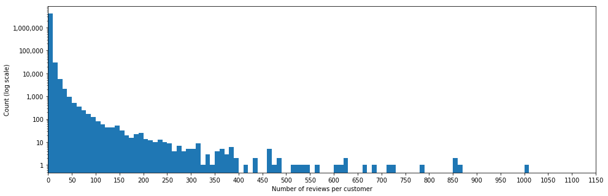

```python
#First plotted on a standard scale
reviews_per_cus = reviews.customer_id.value_counts().tolist()
binsize = 10
bins = np.arange(0, reviews_per_cus[0]+binsize, binsize)

#As the first bin has almost 4
plt.figure(figsize=[16, 5])
(n, bins, patches) = plt.hist(reviews_per_cus, bins = bins)
plt.xlabel('Number of reviews per customer')
plt.yscale('log')
plt.ylabel('Count (log scale)')
plt.yticks([1e0, 1e1, 1e2, 1e3, 1e4, 1e5, 1e6], ['1', '10', '100', '1,000', '10,000', '100,000', '1,000,000'])
plt.xticks(np.arange(0, 1200, 50))
plt.xlim(left = 0)
plt.show()
```

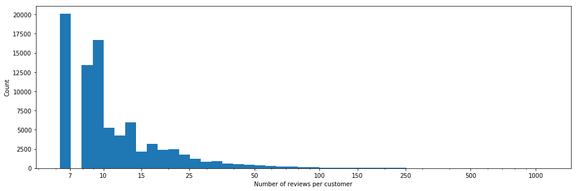

```python
#The above histogram and its bin values show that there's a long tail in the distribution, that goes out quite
#far so I'll move it to a log scale.
log_binsize = 0.05
bins = 10 ** np.arange(0.8, np.log10(reviews_per_cus[0])+log_binsize, log_binsize)

plt.figure(figsize=[16, 5])
plt.hist(reviews_per_cus, bins = bins)
plt.xscale('log')
plt.ylabel('Count')
plt.xticks([7e0, 1e1, 1.5e1, 2.5e1, 5e1, 1e2, 1.5e2, 2.5e2, 5e2, 1e3], ['7', '10', '15', '25', '50', '100', '150', '250', '500', '1000'])
plt.xlabel('Number of reviews per customer')
plt.show()
```

```python
#General statistics of the number of reviews per person.
print("Mean:",statistics.mean(reviews_per_cus))
print("Median:",statistics.median(reviews_per_cus))
print("Mode:",statistics.mode(reviews_per_cus))
print("stdev:",statistics.stdev(reviews_per_cus))
print("Variance:",statistics.variance(reviews_per_cus))
```

```
Mean: 1.6840200972649837
Median: 1.0
Mode: 1
stdev: 3.509075317929728
Variance: 12.313609586903622
```

As there are a lot of customers who only made 1 review, it skews the data heavily. Approximately there are 3.9 million customers that made only 1 review. Looking at the general statistics of the number of reviews per customer, on average people only make 2 (rounded up from 1.6) reviews.

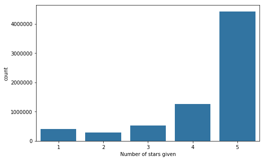

```python
#A look at total count of each number of stars given in the dataset.
plt.figure(figsize=[8, 5])
sb.countplot(data=reviews, x="star_rating", color=sb.color_palette()[0])
plt.xlabel('Number of stars given')
plt.show()
```

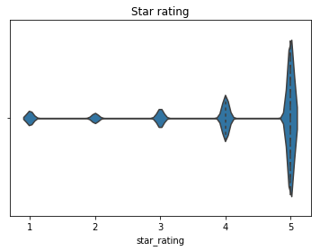

```python
#Violin plot of the given star ratings.
sb.violinplot(x = reviews["star_rating"], inner = 'quartile')
plt.title('Star rating')
plt.show()
```

The 2 above graphs indicate that there is a very large number of 5 star ratings given to reviews. Infact, looking at the violingplot, we can see that more 75% of the reviews are given a 4 or 5 star rating. An interesting point was the 2 star ratings were the least given in this dataset.

Next I want to see the helpful votes for each review. Since there is quite a large difference between the lower end and the upper end, the y-axis is on a log scale.

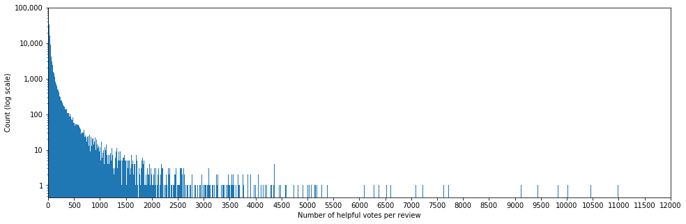

```python
binsize = 10
bins = np.arange(0, reviews.helpful_votes.max()+binsize, binsize)

plt.figure(figsize=[16, 5])
plt.hist(data=reviews, x="helpful_votes", bins = bins)
plt.yscale('log')
plt.ylabel('Count (log scale)')
plt.yticks([1e0, 1e1, 1e2, 1e3, 1e4, 1e5], ['1', '10', '100', '1,000', '10,000', '100,000', '1,000,000', '10,000,000'])
plt.xlim(left=0, right=12000)
plt.xticks(np.arange(0, 12500, 500))
plt.ylim(top=100000)
plt.xlabel('Number of helpful votes per review')
plt.show()
```

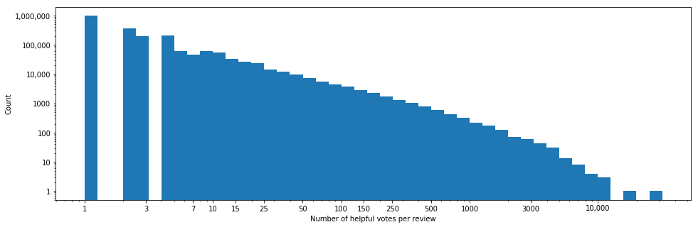

```python
#The above histogram and its bin values show that there's a long tail in the distribution, that goes out quite
#far so I'll move it to a log scale.
log_binsize = 0.1
bins = 10 ** np.arange(0, np.log10(reviews.helpful_votes.max())+log_binsize, log_binsize)

plt.figure(figsize=[16, 5])
plt.hist(data=reviews, x="helpful_votes", bins = bins)
plt.xscale('log')
plt.yscale('log')
plt.ylabel('Count')
plt.yticks([1e0, 1e1, 1e2, 1e3, 1e4, 1e5,1e6], ['1', '10', '100', '1000', '10,000', '100,000','1,000,000'])
plt.xticks([1e0, 3e0, 7e0, 1e1, 1.5e1, 2.5e1, 5e1, 1e2, 1.5e2, 2.5e2, 5e2, 1e3, 3e3, 1e4], ['1', '3','7', '10', '15', '25', '50', '100', '150', '250', '500', '1000', '3000', '10,000'])
plt.xlabel('Number of helpful votes per review')
plt.show()
```

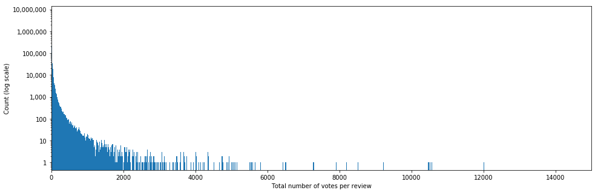

```python
binsize = 10
bins = np.arange(0, reviews.total_votes.max()+binsize, binsize)

plt.figure(figsize=[16, 5])
plt.hist(data=reviews, x="total_votes", bins = bins)
plt.yscale('log')
plt.ylabel('Count (log scale)')
plt.yticks([1e0, 1e1, 1e2, 1e3, 1e4, 1e5, 1e6, 1e7], ['1', '10', '100', '1,000', '10,000', '100,000', '1,000,000', '10,000,000'])
plt.xlim(left=0, right=15000)
plt.xlabel('Total number of votes per review')
plt.show()
```

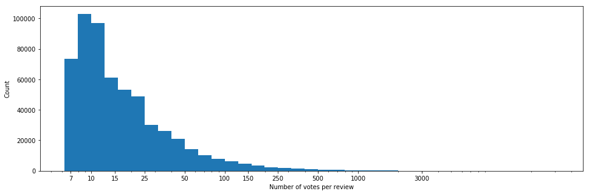

```python
#The above histogram and its bin values show that there's a long tail in the distribution, that goes out quite
#far so I'll move it to a log scale.
log_binsize = 0.1
bins = 10 ** np.arange(0.8, np.log10(reviews.total_votes.max())+log_binsize, log_binsize)

plt.figure(figsize=[16, 5])
plt.hist(data=reviews, x="total_votes", bins = bins)
plt.xscale('log')
plt.ylabel('Count')
plt.xticks([7e0, 1e1, 1.5e1, 2.5e1, 5e1, 1e2, 1.5e2, 2.5e2, 5e2, 1e3,3e3], ['7', '10', '15', '25', '50', '100', '150', '250', '500', '1000', '3000'])
plt.xlabel('Number of votes per review')
plt.show()
```

```python
print("Value counts for total_votes:", len(reviews.total_votes.value_counts()))
print("Value counts for helpful_votes:", len(reviews.helpful_votes.value_counts()))
```

```
Value counts for total_votes: 1712
Value counts for helpful_votes: 1569
```

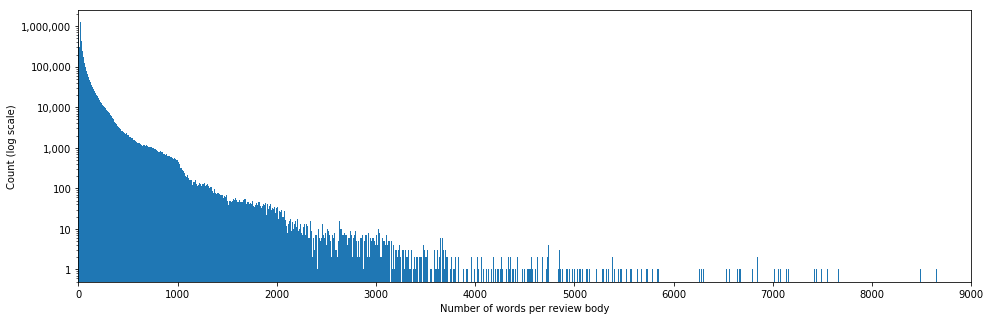

```python
binsize = 5
bins = np.arange(0, reviews.total_votes.max()+binsize, binsize)

plt.figure(figsize=[16, 5])
plt.hist(data=reviews, x="review_body_len", bins = bins)
plt.yscale('log')
plt.ylabel('Count (log scale)')
plt.yticks([1e0, 1e1, 1e2, 1e3, 1e4, 1e5, 1e6], ['1', '10', '100', '1,000', '10,000', '100,000', '1,000,000'])
plt.xlim(left=0, right=9000)
plt.xlabel('Number of words per review body')
plt.show()
```

We can see here that there are a lot of reviews that have a low number of words in the review. Putting the graph on a y-axis with a log scale shows how much the drop off is.

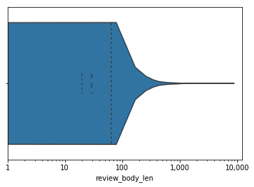

```python
#plot the number of words per review on a violin plot with the x-axis on a log scale
sb.violinplot(x = reviews["review_body_len"], inner = 'quartile')
plt.xscale('log')
plt.xticks([1e0, 1e1, 1e2, 1e3, 1e4], ['1', '10', '100', '1,000', '10,000']);
```

```python
#General statistics of the number of words per review.
print("Mean:",statistics.mean(reviews.review_body_len))
print("Median:",statistics.median(reviews.review_body_len))
print("Mode:",statistics.mode(reviews.review_body_len))
print("stdev:",statistics.stdev(reviews.review_body_len))
print("Variance:",statistics.variance(reviews.review_body_len))
```

```
Mean: 69.30837865089829
Median: 29.0
Mode: 20
stdev: 137.60778942635017
Variance: 18935.903710806728
```

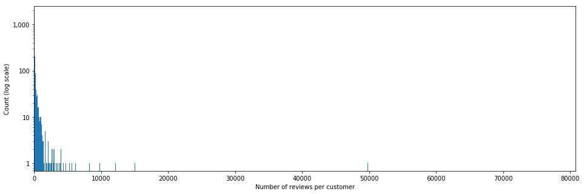

```python
reviews_per_product = reviews.product_parent.value_counts().tolist()
binsize = 5
bins = np.arange(0, reviews_per_product[0]+binsize, binsize)

plt.figure(figsize=[16, 5])
plt.hist(reviews_per_product, bins = bins)
plt.xlabel('Number of reviews per customer')
plt.ylabel('Count (log scale)')
plt.yscale('log')
plt.yticks([1e0, 1e1, 1e2, 1e3], ['1', '10', '100', '1,000'])
plt.xlim(left = 0)
plt.show()
```

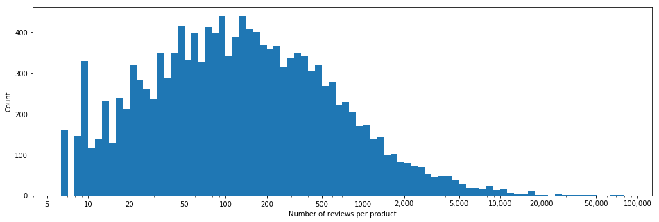

```python
#The above histogram and its bin values show that the distribution is quite compact towards the low end, with a few points
#going out towards 80,000. So I'll move it to a log scale.
log_binsize = 0.05
bins = 10 ** np.arange(0.8, np.log10(reviews_per_product[0])+log_binsize, log_binsize)

plt.figure(figsize=[16, 5])
plt.hist(reviews_per_product, bins = bins)
plt.xscale('log')
plt.ylabel('Count')
plt.xticks([5e0, 1e1, 2e1, 5e1, 1e2, 2e2, 5e2, 1e3, 2e3, 5e3, 1e4, 2e4, 5e4, 1e5], ['5', '10', '20', '50', '100', '200', '500', '1000', '2,000', '5,000', '10,000', '20,000', '50,000', '100,000'])
plt.xlabel('Number of reviews per product')
plt.show()
```

In the log scale it is clear that the distrbution is unimodal and follows a gaussian distribution. It looks like, on average, products have around 100 reviews each.

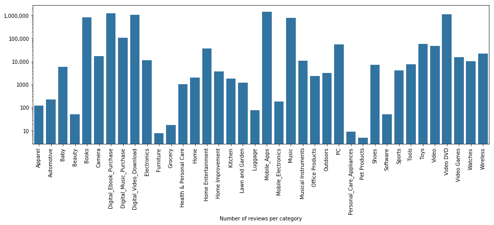

```python
#Number of reviews per category
x=reviews.groupby("product_category").count()['customer_id']

plt.figure(figsize=[16, 5])
sb.barplot(x=x.index, y=x.values, color=sb.color_palette()[0])
plt.yscale('log')
plt.yticks([1e1, 1e2, 1e3, 1e4, 1e5, 1e6], ['10', '100', '1000', '10,000', '100,000', '1,000,000'])
plt.xticks(rotation=90)
plt.xlabel('Number of reviews per category')
plt.show()
```

The bar graph show the spread of how reviews over the different categories. It's interesting how the lowest amount of reviews in a category is pet products.

I am interested in seeing if there is a trend in the reviews over time.

```python
#Create a new table to group the months against the number of reviews posted.
review_date_df = reviews[['review_id', 'review_date']].copy()
review_date_df['review_date']=pd.to_datetime(review_date_df.review_date)
review_date_df.index=review_date_df['review_date']
data = review_date_df.groupby(pd.Grouper(freq='M')).review_id.count()
```

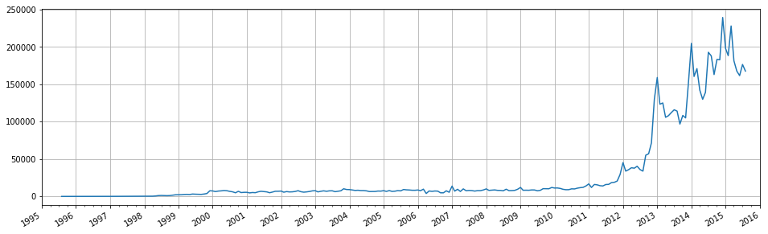

```python
#A time series graph of the trend in reviews over time.
x=pd.date_range(start='1/1/1995', periods=22, freq='12M').tolist()

plt.figure(figsize=[16, 5])
plt.xticks(x, rotation='vertical')
plt.plot(data)
plt.xlim(left=x[0], right=x[len(x)-1])
plt.grid(b=True)
plt.gca().xaxis.set_minor_locator(AutoMinorLocator())
plt.gcf().autofmt_xdate()
```

An interesting trend here is that at a lot of new years points there is a spike in the number of reviews. After 2012, this greatly increases.

### Discuss the distribution(s) of your variable(s) of interest. Were there any unusual points? Did you need to perform any transformations?

Looking at the total/helpful votes as well as the word count for each review have quite a large spread in data. The star rating for the dataset is quite interesting, where a very large majority of the stars are given as 5 stars. 2 stars have the lowest amount of stars given.

### Of the features you investigated, were there any unusual distributions? Did you perform any operations on the data to tidy, adjust, or change the form of the data? If so, why did you do this?

From the dataset I would have expect there to be more uniform distribution in the number reviews in each category.  
In the time series graph it was interesting to note that around new year lead to a spike in reviews starting from around 2007 and this becoming very apparent from 2012.

There were a number of operations taken to tidy the data, one of the major tidying the data was to remove reviews that did not parse correctly. As some reviews in the title or body contained a tab break. As a TSV seperator is a tab break, this lead to a lot of reviews being mixed in with other reviews as part of the body. In order to seperate these it would take a lot of time and since I have more than 6 million points of data, I decied to drop these.

## Bivariate Exploration

> In this section, investigate relationships between pairs of variables in your data. Make sure the variables that you cover here have been introduced in some fashion in the previous section (univariate exploration).

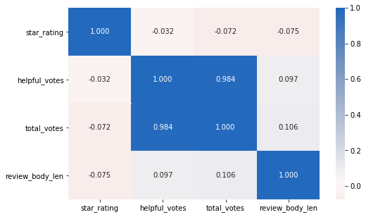

```python
#Correlation plot
plt.figure(figsize = [8, 5])
sb.heatmap(reviews[["star_rating","helpful_votes","total_votes", "review_body_len"]].corr(), annot = True, fmt = '.3f',
           cmap = 'vlag_r', center = 0)
plt.yticks(rotation=0)
plt.show()
```

As we can see from the correlation plot there is a clear trend between the number of helpful votes and total number of votes. This was to be expected as with more votes generally there will be more helpful votes.  
But it looks like there are not many trends outside of those 2 items. The worst is star rating agains review body length with a negative correlation.

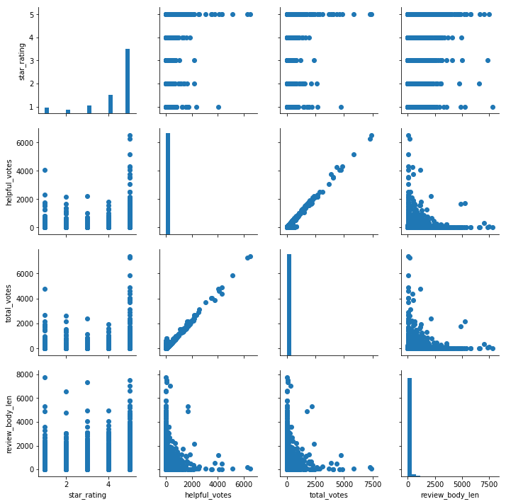

```python
# plot matrix: A sample of 500,000 reviews is used so that plots load render faster
review_samp = reviews.sample(n=500000, random_state=42)

g = sb.PairGrid(data = review_samp, vars = ["star_rating","helpful_votes","total_votes", "review_body_len"])
g = g.map_diag(plt.hist, bins = 20)
g.map_offdiag(plt.scatter);
```

This plot matrix shows visually the relationship. Here you can clearly see the trend between total and helpful votes. But there is almost nothing to see with the relationship between star rating and review length. It looks like the star rating has no bearing on the review length as they look somewhat even between the ratings.

```python
#Set the numeric and categoric variables to investigate.
numeric_vars = ["helpful_votes", "total_votes", "review_body_len"]
categoric_vars = ['customer_id', 'product_parent', 'product_category']
```

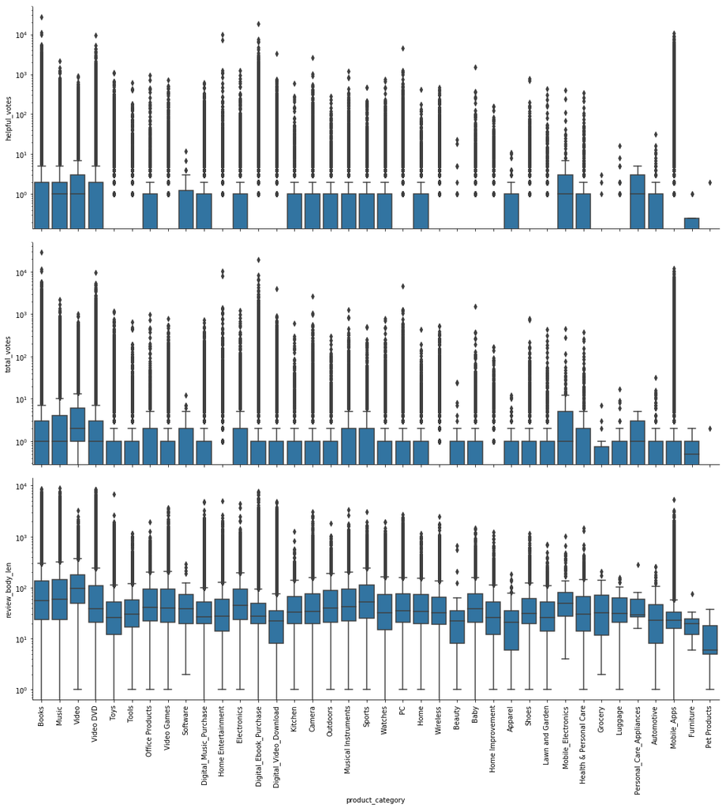

```python
#View numeric values of helpful_votes, total_votes, review_body_len against each product category
#All y-axis figures are in a log scale to make it more readable.

def boxgrid(x, y, **kwargs):
    """ Quick hack for creating box plots with seaborn's PairGrid. """
    default_color = sb.color_palette()[0]
    sb.boxplot(x, y, color = default_color)

plt.figure(figsize = [10, 10])
g = sb.PairGrid(data = reviews, y_vars = numeric_vars, x_vars = "product_category",
                height = 5, aspect = 3)
g.map(boxgrid)
#g.set_xticklabels(rotation=90)
plt.xticks(rotation=90)
g.set(yscale="log")
plt.show();
```

Since a lot of the total votes are only around 1 for each review, I want to look at reviewers that have had more than 10 votes given to one or more of their reviews. This is to see if reviewers who get 10 or more votes are constant in getting that many votes or is it just a one time thing.

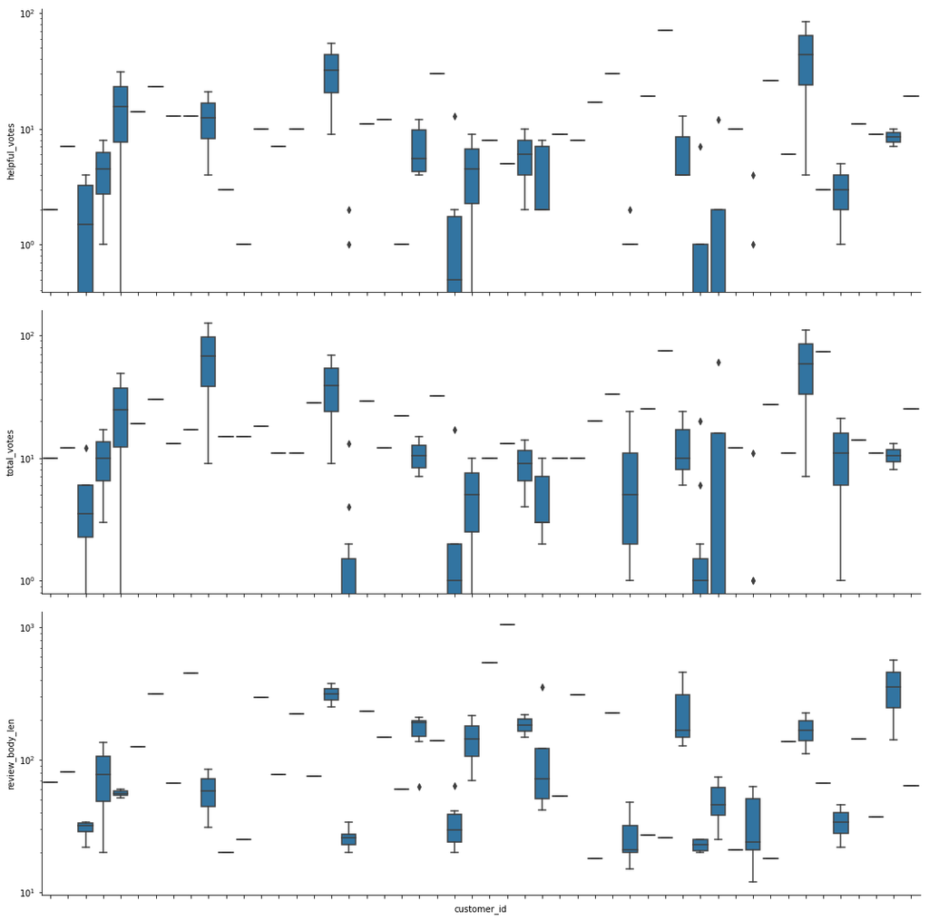

```python
#Select a random sample of customers who have recieved more than 10 total votes to a review they made.
cust_samp = np.random.choice(reviews[reviews["total_votes"] >= 10]["customer_id"].unique(), 50)
customers_50 = reviews.loc[reviews['customer_id'].isin(cust_samp)]


def boxgrid(x, y, **kwargs):
    """ Quick hack for creating box plots with seaborn's PairGrid. """
    default_color = sb.color_palette()[0]
    sb.boxplot(x, y, color = default_color);

plt.figure(figsize = [10, 10])
g = sb.PairGrid(data = customers_50, y_vars = numeric_vars, x_vars = 'customer_id',
                height = 5, aspect = 3)
g.map(boxgrid)
g.set(xticklabels=[]) #Each customer is assigned a random ID, so to tidy up the graph they are omitted.
g.set(yscale="log")
plt.show();
```

```python
#Values of the random sample of 50 customers.
customers_50.describe()
```

|  | star_rating | helpful_votes | total_votes | review_body_len |
| --- | --- | --- | --- | --- |
| count | 118.000000 | 118.000000 | 118.000000 | 118.000000 |
| mean | 3.694915 | 6.898305 | 12.576271 | 101.567797 |
| std | 1.598656 | 12.495736 | 19.983073 | 142.378362 |
| min | 1.000000 | 0.000000 | 0.000000 | 12.000000 |
| 25% | 2.000000 | 0.000000 | 0.250000 | 24.000000 |
| 50% | 5.000000 | 2.000000 | 8.000000 | 46.000000 |
| 75% | 5.000000 | 9.000000 | 14.750000 | 133.750000 |
| max | 5.000000 | 84.000000 | 125.000000 | 1050.000000 |

Looking at the customer review body length for this sample, it looks like on average these customer's reviews are about 100 words long, confirmed by the describe function.

As there are over 4 million customers, a random sample of 50 will not be as indicitive of the whole dataset. So I want to next look at a random sample of 50 items. This could give a better insight into the products as there are only around 16,000 different products. Specifically, I want to see products that have 10 or more reviews.

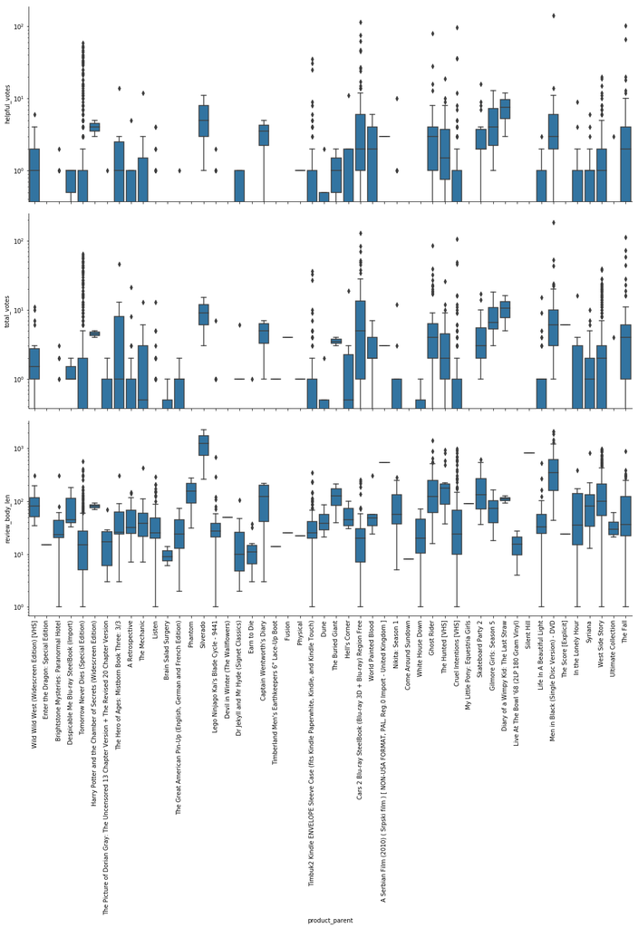

```python
#Products that have had 10 or more customer reviews.
x=reviews.groupby("product_id").count()["customer_id"]>=10
prod_samp = np.random.choice(x.index, 50)
products_50 = reviews.loc[reviews['product_id'].isin(prod_samp)]

#As some products have different variations of the name used, use the name that appears first.
item_name_list = []
for i in prod_samp:
    item_name_list.append(reviews.loc[reviews['product_id'].isin([i])].product_title.iloc[0])



def boxgrid(x, y, **kwargs):
    """ Quick hack for creating box plots with seaborn's PairGrid. """
    default_color = sb.color_palette()[0]
    sb.boxplot(x, y, color = default_color);

plt.figure(figsize = [10, 10])
g = sb.PairGrid(data = products_50, y_vars = numeric_vars, x_vars = 'product_parent',
                height = 5, aspect = 3)
g.map(boxgrid)
plt.xticks(rotation=90)
g.set(xticklabels=item_name_list)
g.set(yscale="log")
plt.show();
```

```python
#Values of the random sample of 50 products.
products_50.describe()
```

|  | star_rating | helpful_votes | total_votes | review_body_len |
| --- | --- | --- | --- | --- |
| count | 2140.000000 | 2140.000000 | 2140.000000 | 2140.000000 |
| mean | 4.150467 | 2.398131 | 3.684112 | 94.922897 |
| std | 1.206099 | 7.868092 | 9.813322 | 178.790292 |
| min | 1.000000 | 0.000000 | 0.000000 | 1.000000 |
| 25% | 4.000000 | 0.000000 | 0.000000 | 17.000000 |
| 50% | 5.000000 | 0.000000 | 1.000000 | 32.000000 |
| 75% | 5.000000 | 2.000000 | 3.000000 | 92.000000 |
| max | 5.000000 | 143.000000 | 184.000000 | 2251.000000 |

Comparing this sample of products the number of helpful votes is the same compared to the total dataset, but the total votes is actually slightly higher. This makes sense as there are a lot of reviews that only get 1 vote. An interesting point is that it seems the review body length between the sample of customers and the sample of products is very close only being different by around 10 words.

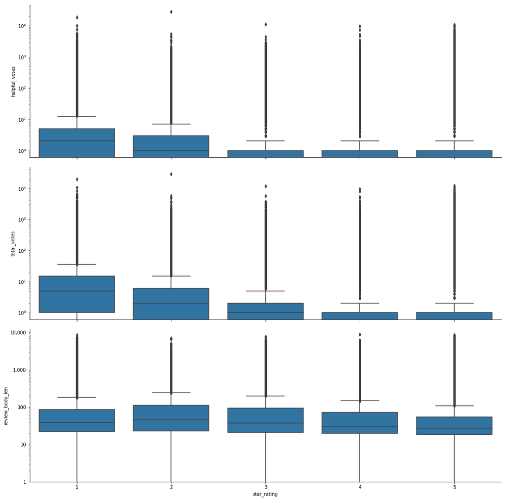

```python
#View numeric values of helpful_votes, total_votes, review_body_len against each star rating.

def boxgrid(x, y, **kwargs):
    """ Quick hack for creating box plots with seaborn's PairGrid. """
    default_color = sb.color_palette()[0]
    sb.boxplot(x, y, color = default_color)
#     plt.yticks([1e0, 1e1, 1e2, 1e3, 1e4], ['1', '10', '100', '1,000', '10,000'])

plt.figure(figsize = [10, 10])
g = sb.PairGrid(data = reviews, y_vars = numeric_vars, x_vars = "star_rating",
                height = 5, aspect = 3)
g.map(boxgrid)
#g.set_xticklabels(rotation=90)
# plt.xticks(rotation=90)
g.set(yscale="log")
plt.yticks([1e0, 1e1, 1e2, 1e3, 1e4], ['1', '10', '100', '1,000', '10,000'])
plt.show();
```

This graph looks at the star ratings for each product across the dataset. The interesting thing about this is that there are more total and helpful votes for ratings that give 1 or 2 stars compared to 4 or 5 stars. This is quite interesting as there are a lot more stars given as 4 or 5 star ratings.  
Though the review body length is actually pretty similar across each star rating.

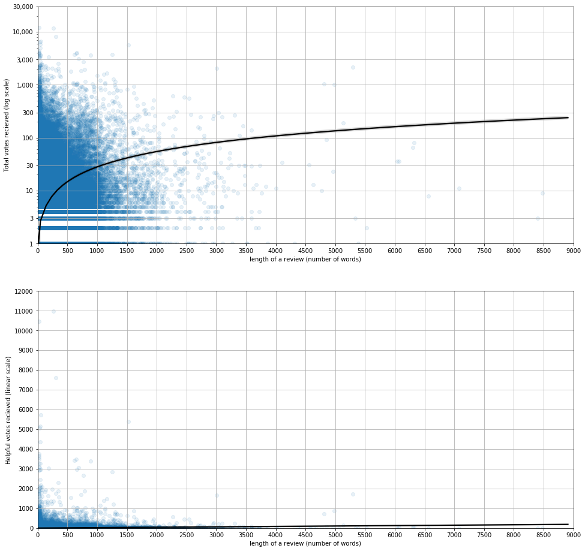

```python
#Use a sample to speed up the calculation time.
review_samp2 = reviews.sample(n=1000000, random_state=84)

plt.figure(figsize = [16, 16])

#Compare the total votes recieved to the length of the review and plot a line of best fit - y-axis on a log scale
ax = plt.subplot(2, 1, 1)
sb.regplot(x="review_body_len", y="total_votes", data=review_samp2, scatter_kws={'alpha':0.1},line_kws={'color':'black'})
plt.xlim(left=0, right=9000)
plt.ylim(top=3e3, bottom= 1e0)
plt.xlabel('length of a review (number of words)')
plt.yscale('log')
plt.yticks([1e0, 3e0, 1e1, 3e1, 1e2, 3e2, 1e3, 3e3, 1e4, 3e4], ['1', '3', '10', '30', '100', '300', '1,000', '3,000', '10,000', '30,000'])
plt.xticks(np.arange(0, 9500, 500))
plt.ylabel('Total votes recieved (log scale)')
plt.grid(True)

#Compare the helpful votes recieved to the length of the review and plot a line of best fit - y-axis on a linear scale
ax = plt.subplot(2, 1, 2)
sb.regplot(x="review_body_len", y="helpful_votes", data=review_samp2, scatter_kws={'alpha':0.1}, line_kws={'color':'black'})
plt.xlim(left=0, right=9000)
plt.ylim(top=12000, bottom=0)
plt.xlabel('length of a review (number of words)')
plt.xticks(np.arange(0, 9500, 500))
plt.yticks(np.arange(0, 13000, 1000))
plt.ylabel('Helpful votes recieved (linear scale)')
plt.grid(True)


plt.show()
```

One of my original investigation questions was to see if there was a relationship between review characteristics and the length of a review. Looking only at the scatter plot of the graph it is difficult to see if there is a relationship between the total/helpful votes.  
Adding in a line of best shows there is a slight relationship between votes and length of a review. Since the line is quite flat it seems that the number of words in a review does not have a large effect on the votes/helpful votes recieved.

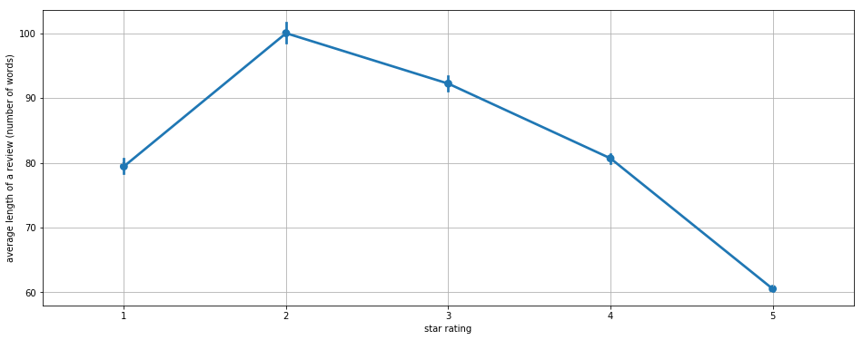

```python
#Use a sample to speed up the calculation time.
review_samp3 = reviews.sample(n=1000000, random_state=85)

#Compare the total helpful votes recieved to the length of the review.
plt.figure(figsize = [16, 6])
sb.pointplot(x="star_rating", y="review_body_len", data=review_samp3)
plt.xlim(right=4.5)
plt.ylabel('average length of a review (number of words)')
plt.xticks([0,1,2,3,4],[1,2,3,4,5])
plt.xlabel('star rating')
plt.grid(True)
plt.show()
```

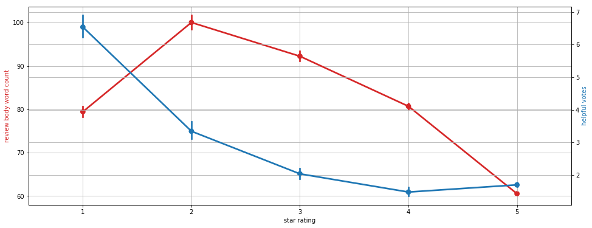

```python
#Use a sample to speed up the calculation time.
review_samp3 = reviews.sample(n=1000000, random_state=85)

#Put 2 plots on the same axis with different scales
fig, ax1 = plt.subplots(figsize=(16, 6))

#Average of the review body word count vs star rating
colour = 'tab:red'
sb.pointplot(x="star_rating", y="review_body_len", data=review_samp3, color=colour)
ax1.set_xlabel('star rating')
ax1.set_ylabel('review body word count', color=colour)
ax1.grid(True)

#Average of the review helpful votes vs star rating
ax2 = ax1.twinx()  # instantiate a second axes that shares the same x-axis
colour = 'tab:blue'
sb.pointplot(x="star_rating", y="helpful_votes", data=review_samp3, color=colour)
ax2.set_xlabel('star_rating')
ax2.set_ylabel('helpful votes', color=colour)
ax2.grid(True)

plt.show();
```

Looking at the trends for each star rating against the review body word count and helpful votes, it is interesting to see that on average 2 star reviews have longer review word counts, but a lower number of helpful votes. For 1 star reviews, this is the opposite; more helpful votes but a lower word count.

As I had not investigated very deeply into vine and verified purchases yet, I wanted to see if there was a relationship that could be found.  
To see a clear difference for each category, a log scale was used on the y-axis.

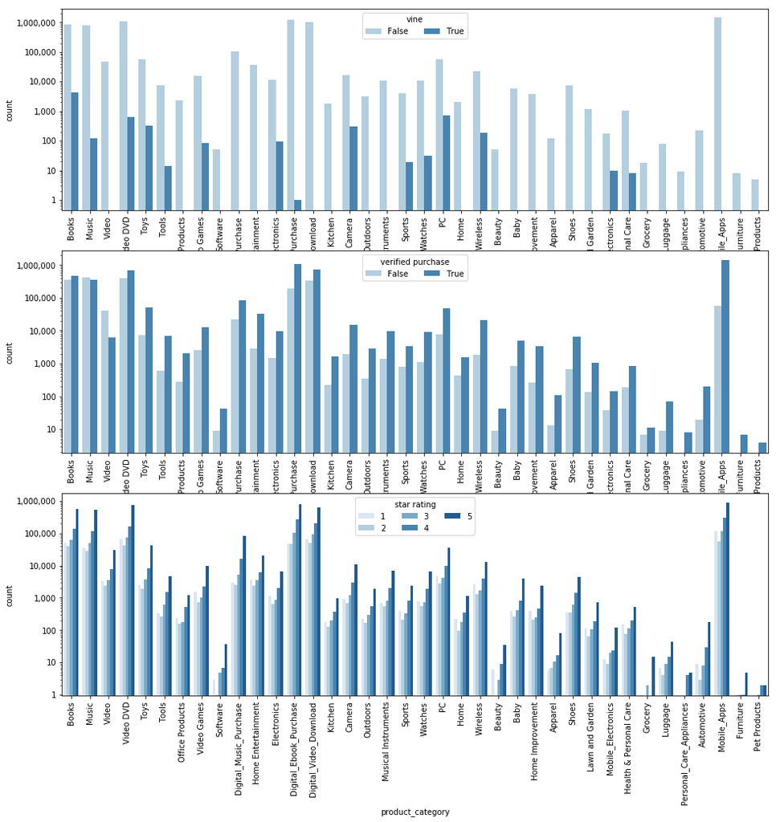

```python
# since there's only three subplots to create, using the full data should be fine.
plt.figure(figsize = [16, 16])

# subplot 1: product_category vs vine
ax = plt.subplot(3, 1, 1)
plt.yscale('log')
plt.xticks(rotation=90)
plt.yticks([1e0, 1e1, 1e2, 1e3, 1e4, 1e5, 1e6], ['1', '10', '100', '1,000', '10,000', '100,000', '1,000,000'])
sb.countplot(data = reviews, x = 'product_category', hue = 'vine', palette = 'Blues')
ax.legend(ncol = 2, title = "vine") # re-arrange legend to reduce overlapping

# subplot 2: product_category vs. verified_purchase
ax = plt.subplot(3, 1, 2)
plt.yscale('log')
plt.xticks(rotation=90)
plt.yticks([1e0, 1e1, 1e2, 1e3, 1e4, 1e5, 1e6], ['1', '10', '100', '1,000', '10,000', '100,000', '1,000,000'])
sb.countplot(data = reviews, x = 'product_category', hue = 'verified_purchase', palette = 'Blues')
ax.legend(ncol = 2, title = "verified purchase")

# subplot 3: product_category vs. star_rating
ax = plt.subplot(3, 1, 3)
plt.yscale('log')
plt.yticks([1e0, 1e1, 1e2, 1e3, 1e4, 1e5, 1e6], ['1', '10', '100', '1,000', '10,000', '100,000', '1,000,000'])
sb.countplot(data = reviews, x = 'product_category', hue = 'star_rating', palette = 'Blues')
ax.legend(loc=9, ncol = 3, title = "star rating") # re-arrange legend to remove overlapping

plt.xticks(rotation=90)
plt.show()
```

### Talk about some of the relationships you observed in this part of the investigation. How did the feature(s) of interest vary with other features in the dataset?

The main, and easily observable, relationship is between the total number of votes and the number of helpful votes. This is something that I expect to observe as the more votes there are, on average you would expect the number of helpful votes to go up with it.  
Originally I was expect there to be a big relationship between the number of votes and star rating, but it seems like there is only a slight difference between from the norm in 1 and 2 star columns.  
While there are a lot of datapoints for the scatter graphs, the line of best fit shows that there is a slight relationship. Generally, the more words per review does not mean that there will be a large number of total/helpful votes.

### Did you observe any interesting relationships between the other features (not the main feature(s) of interest)?

An interesting point was that, on average, 2 star ratings have more words per review than the other star ratings and that 5 star ratings were the lowest.

## Multivariate Exploration

First I want to see some charastics of the top 3 customers who made the most reviews.

```python
#Display the top 3 reviewers with the most reviews
reviews.groupby("customer_id").count()["review_id"].nlargest(3)
```

```
customer_id
50881246    1005
19792742     863
14539589     857
Name: review_id, dtype: int64
```

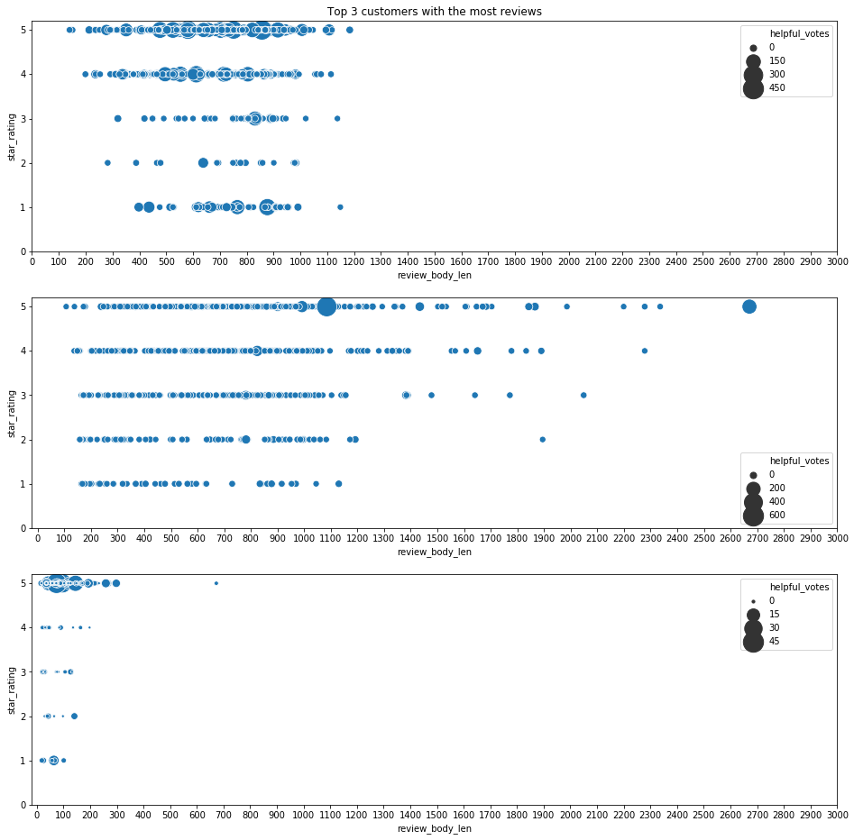

```python
# since there's only three subplots to create, using the full data should be fine.
plt.figure(figsize = [16, 16])
# plt.title("Top 3 customers with the most reviews")

# subplot 1: product_category vs vine
ax = plt.subplot(3, 1, 1)
plt.title("Top 3 customers with the most reviews")
data = reviews.loc[reviews['customer_id'].isin(["50881246"])]
sb.scatterplot(data = data, x = 'review_body_len', y = 'star_rating', size="helpful_votes", sizes=(50, 500),legend="brief") #palette=cmap);
plt.yticks(np.arange(0, 6, 1))
plt.xticks(np.arange(0, 3100, 100));
ax.legend(ncol = 1) # re-arrange legend to reduce overlapping

# subplot 2: product_category vs. verified_purchase
ax = plt.subplot(3, 1, 2)
data = reviews.loc[reviews['customer_id'].isin(["19792742"])]
sb.scatterplot(data = data, x = 'review_body_len', y = 'star_rating', size="helpful_votes", sizes=(50, 500),legend="brief") #palette=cmap);
plt.yticks(np.arange(0, 6, 1))
plt.xticks(np.arange(0, 3100, 100));
ax.legend(ncol = 1)

# subplot 3: product_category vs. star_rating
ax = plt.subplot(3, 1, 3)
data = reviews.loc[reviews['customer_id'].isin(["14539589"])]
sb.scatterplot(data = data, x = 'review_body_len', y = 'star_rating', size="helpful_votes", sizes=(10, 500),legend="brief") #palette=cmap);
plt.yticks(np.arange(0, 6, 1))
plt.xticks(np.arange(0, 3100, 100));
ax.legend(ncol = 1) # re-arrange legend to remove overlapping

# plt.xticks(rotation=90)
plt.show()
```

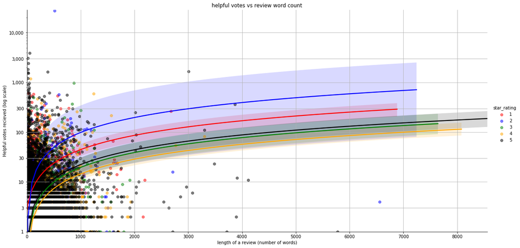

```python
#Use a sample to speed up the calculation time.
review_samp4 = reviews.sample(n=100000, random_state=184)

#Compare the helpful votes recieved to the length of the review and plot a line of best fit split by star rating - log scale
colours = {1: "red", 2: "blue", 3: "green", 4: "orange", 5:"black"}
sb.lmplot(x="review_body_len", y="helpful_votes", data=review_samp4, scatter_kws={'alpha':0.5}, hue='star_rating', palette=colours, height=8, aspect=2)
plt.xlim(left=1e0)
plt.ylim(bottom=1e0)
plt.yscale('log')
plt.yticks([1e0, 3e0, 1e1, 3e1, 1e2, 3e2, 1e3, 3e3, 1e4], ['1', '3', '10', '30', '100', '300', '1,000', '3,000', '10,000'])
plt.xlabel('length of a review (number of words)')
plt.ylabel('Helpful votes recieved (log scale)')
plt.title('helpful votes vs review word count')
plt.grid(True);
```

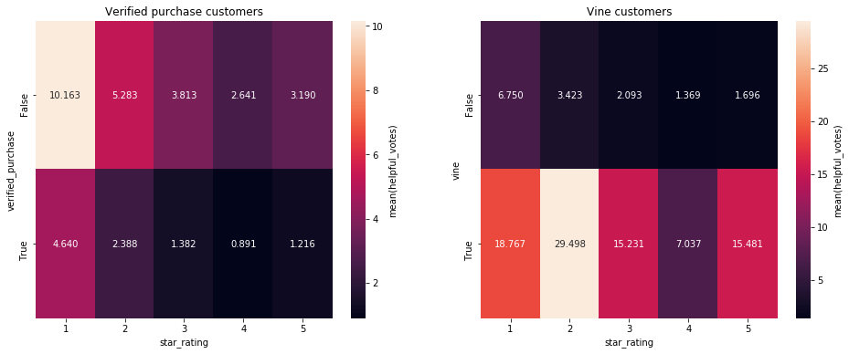

```python
plt.figure(figsize = [16, 6])

#Investigate the relationship between the verified purchases, star ratings and the number of helpful votes
ax = plt.subplot(1, 2, 1)
plt.title('Verified purchase customers')
cat_means = reviews.groupby(['star_rating', 'verified_purchase']).mean()['helpful_votes']
cat_means = cat_means.reset_index(name = 'helpful_votes')
cat_means = cat_means.pivot(index = 'verified_purchase', columns = 'star_rating',
                            values = 'helpful_votes')
sb.heatmap(cat_means, annot = True, fmt = '.3f',
           cbar_kws = {'label' : 'mean(helpful_votes)'});

#Investigate the relationship between vine customers, star ratings and the number of helpful votes
ax = plt.subplot(1, 2, 2)
plt.title('Vine customers')
cat_means = reviews.groupby(['star_rating', 'vine']).mean()['helpful_votes']
cat_means = cat_means.reset_index(name = 'helpful_votes')
cat_means = cat_means.pivot(index = 'vine', columns = 'star_rating',
                            values = 'helpful_votes')
sb.heatmap(cat_means, annot = True, fmt = '.3f',
           cbar_kws = {'label' : 'mean(helpful_votes)'});

plt.show()
```

The first diagram show that there is an interesting relationship between verified purchases and 1 star ratings. More people find these reviews to be helpful. It also seems that people don't find people with verified purchases to leave helpful reviews compared to people who have made verified purchases.  
The helpful votes for vine purchases is quite interesting. People find vine reviewers to be quite useful across all ratings. This could because the vine program only uses customers chosen by Amazon to be apart of the program, meaning that their reviews prior to the vine program were good.

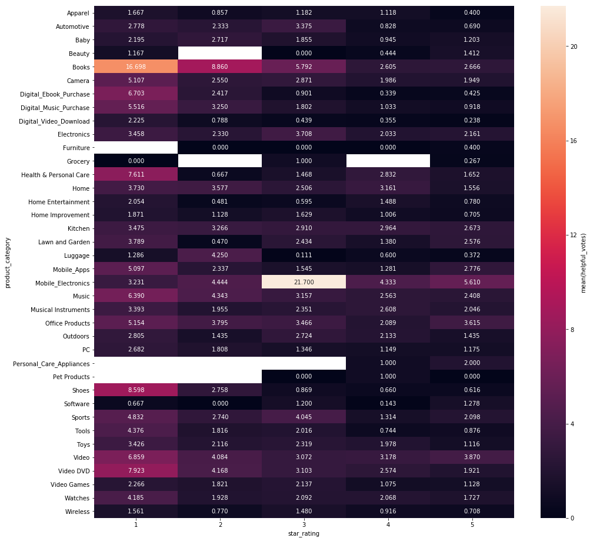

```python
#split each category into its star rating and view the average number of helpful reviews
plt.figure(figsize = [16, 16])
cat_means = reviews.groupby(['star_rating', 'product_category']).mean()['helpful_votes']
cat_means = cat_means.reset_index(name = 'helpful_votes')
cat_means = cat_means.pivot(index = 'product_category', columns = 'star_rating',
                            values = 'helpful_votes')
sb.heatmap(cat_means, annot = True, fmt = '.3f',
           cbar_kws = {'label' : 'mean(helpful_votes)'});
```

This I think is interesting. While most reviews give 5 stars, the actual number of helpful votes is found more in the 1 star column, with 3 star reviews on mobile electronics getting the most helpful votes. Although, on average, most other categories have the most helpful reviews within the 1 star column. This confirms what was observed by the above box plots.

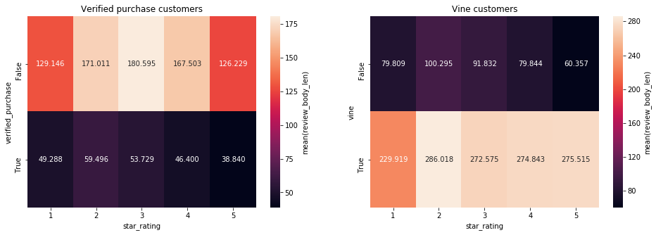

```python
plt.figure(figsize = [16, 5])

#Investigate the relationship between the verified purchases, star ratings and the review body length.
ax = plt.subplot(1, 2, 1)
plt.title('Verified purchase customers')
cat_means = reviews.groupby(['star_rating', 'verified_purchase']).mean()['review_body_len']
cat_means = cat_means.reset_index(name = 'review_body_len')
cat_means = cat_means.pivot(index = 'verified_purchase', columns = 'star_rating',
                            values = 'review_body_len')
sb.heatmap(cat_means, annot = True, fmt = '.3f',
           cbar_kws = {'label' : 'mean(review_body_len)'});

#Investigate the relationship between vine customers, star ratings and the review body length.
ax = plt.subplot(1, 2, 2)
plt.title('Vine customers')
cat_means = reviews.groupby(['star_rating', 'vine']).mean()['review_body_len']
cat_means = cat_means.reset_index(name = 'review_body_len')
cat_means = cat_means.pivot(index = 'vine', columns = 'star_rating',
                            values = 'review_body_len')
sb.heatmap(cat_means, annot = True, fmt = '.3f',
           cbar_kws = {'label' : 'mean(review_body_len)'});

plt.show()
```

These 2 diagrams follow a similar pattern to the above diagrams of average helpful votes. People who leave un-verified purchase reviews and customers who are apart of the vine program are more likely to make longer reviews.

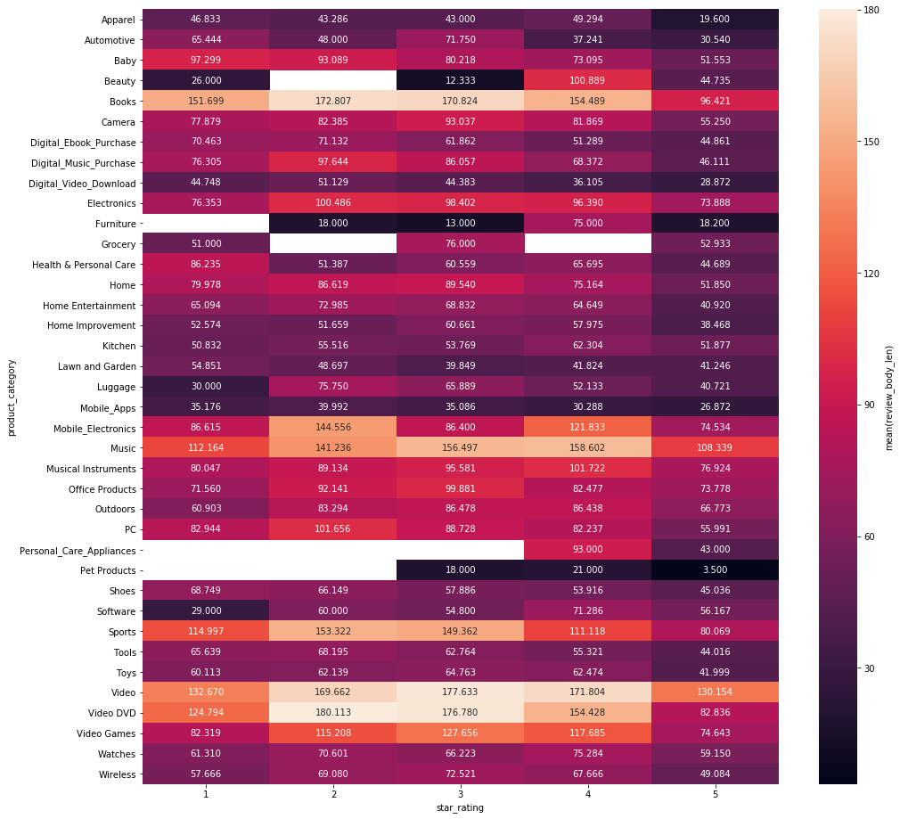

```python
#split each category into its star rating and view the average review length.
plt.figure(figsize = [16, 16])
cat_means = reviews.groupby(['star_rating', 'product_category']).mean()['review_body_len']
cat_means = cat_means.reset_index(name = 'review_body_len')
cat_means = cat_means.pivot(index = 'product_category', columns = 'star_rating',
                            values = 'review_body_len')
sb.heatmap(cat_means, annot = True, fmt = '.3f',
           cbar_kws = {'label' : 'mean(review_body_len)'});
```

This diagram doesn't follow the same pattern as observed above. In this case the average length of a review is longest in the video and DVD section followed by the books category. In both cases the longest reviews are in the 2 and 3 star column.

### Talk about some of the relationships you observed in this part of the investigation. Were there features that strengthened each other in terms of looking at your feature(s) of interest?

In regards the to helpful votes for each star rating, it does seem there is some relationship between them and the categories. There are very few categories that have more helpful votes in the 5 star column over the 1 star column.  
Vine program reviewers also have more helpful votes over non-vine participants, but they still follow the trend that there are more helpful votes in the 1 and 2 star columns.

### Were there any interesting or surprising interactions between features?

A surprising point was that there people find non-verified purchases more helpful than that of people who made verified purchases, even though there are more verified purchases within the dataset.

> At the end of your report, make sure that you export the notebook as an html file from the `File > Download as... > HTML` menu. Make sure you keep track of where the exported file goes, so you can put it in the same folder as this notebook for project submission. Also, make sure you remove all of the quote-formatted guide notes like this one before you finish your report!